# main

## Branje podatkov iz xml datoteke

```python
from xmReader import *
from data_cleaning import *
from population import *

input_file_newYear = "files/air_quality_slo/air_quality_new_year.xml"
input_file_december = "files/air_quality_slo/air_quality_december.xml"

stations_newYear = get_stations(input_file_newYear, replace_less_than_divide_by=2)
stations_december = get_stations(input_file_december, replace_less_than_divide_by=2)
```

## Čiščenje podatkov

V tem koraku izvajama čiščenje podatkov o kakovosti zraka, da zagotovimo kakovostne podatke za nadaljnjo analizo.

**Koraki čiščenja:**

1. **Odstranjevanje postaj z manjkajočimi vrednostmi**:
   - Odstranimo vse postaje, kjer sta PM10 in PM2.5 oba `None`
   - To zagotovi, da imamo vsaj eno meritev delcev za vsako postajo
2. **Preverjanje ekstremnih vrednosti**:
   - Preverimo vse parametre (PM10, PM2.5, NO2, O3, NOx, SO2, CO, Benzen) za ekstremne vrednosti
   - Ekstremne vrednosti so definirane kot vrednosti, ki so precej višje od normalnih mej
   - To nam pomaga identificirati morebitne napake v merjenju ali ekstremne situacije

```python
# ciscenje podatkov
cleaned_stations_newYear = data_cleaning(stations_newYear)
cleaned_stations_december = data_cleaning(stations_december)
```

```
Odstranjevanje postaj z manjkajočima PM10 in PM2.5 vrednostma...
Odstranjeno postaj: 0

PM10:
  Meja za ekstremne vrednosti: 300 μg/m³
  Število ekstremnih vrednosti: 0
  Meritev z vrednostmi (ne None): 3528

PM2_5:
  Meja za ekstremne vrednosti: 150 μg/m³
  Število ekstremnih vrednosti: 0
  Meritev z vrednostmi (ne None): 3528

NO2:
  Meja za ekstremne vrednosti: 500 μg/m³
  Število ekstremnih vrednosti: 0
  Meritev z vrednostmi (ne None): 1715

O3:
  Meja za ekstremne vrednosti: 300 μg/m³
  Število ekstremnih vrednosti: 0
  Meritev z vrednostmi (ne None): 1196

NOX:
  Meja za ekstremne vrednosti: 1000 μg/m³
  Število ekstremnih vrednosti: 0
  Meritev z vrednostmi (ne None): 1554

SO2:
  Meja za ekstremne vrednosti: 500 μg/m³
  Število ekstremnih vrednosti: 0
  Meritev z vrednostmi (ne None): 483

CO:
  Meja za ekstremne vrednosti: 20 μg/m³
  Število ekstremnih vrednosti: 0
  Meritev z vrednostmi (ne None): 161

BENZEN:
  Meja za ekstremne vrednosti: 50 μg/m³
```

[output cut: 34 more lines]

```
  Meja za ekstremne vrednosti: 500 μg/m³
  Število ekstremnih vrednosti: 0
  Meritev z vrednostmi (ne None): 483

CO:
  Meja za ekstremne vrednosti: 20 μg/m³
  Število ekstremnih vrednosti: 0
  Meritev z vrednostmi (ne None): 161

BENZEN:
  Meja za ekstremne vrednosti: 50 μg/m³
  Število ekstremnih vrednosti: 0
  Meritev z vrednostmi (ne None): 405
  Skupno število ekstremnih zapisov: 0
  Parametri z ekstremnimi vrednostmi: Noben
```

## Izpopolnjevanje podatkov

### Pridobivanje podatkov o populaciji

Izpopolnjevanje podatkov o merilnih postajah z dodatnimi informacijami o populaciji v okolici postaj.

- **Pridobivanje števila prebivalcev**: Za vsako merilno postajo pridobimo število prebivalcev v različnih radijih okoli lokacije postaje (1000m, 3000m)
- **Uporaba Google Earth Engine API**: Podatki se pridobivajo preko Google Earth Engine API-ja, ki omogoča dostop do globalnih podatkov o populaciji (GPWv411 - Gridded Population of the World)
- **Koordinatna identifikacija**: Za vsako postajo se uporabita geografski koordinati (latitude, longitude) za določitev lokacije
- **Izračun gostote populacije**: Na podlagi števila prebivalcev in velikosti območja izračunamo gostoto populacije (prebivalci/km²)
- **Kategorizacija**: Gostote populacije razvrstimo v kategorije (npr. nizka, srednja, visoka) za lažjo analizo

Podatki o populaciji v okolici merilnih postaj omogočajo analizo povezave med onesnaženjem zraka in gostoto prebivalstva, kar je ključno za oceno izpostavljenosti prebivalstva onesnaženju.

```python
from population import get_population_radius, calculate_temperature

def calculate_population_density(stations, area_sizes):
    # Get unique stations for population calc
    unique_stations = {}
    for station in stations:
        name = station.get("ime")
        lat = station.get("lat")
        lon = station.get("lon")
        sifra = station.get("sifra")

        if name not in unique_stations:
            unique_stations[name] = {"lat": lat, "lon": lon, "sifra": sifra}

    station_population_map = {}
    for name, info in unique_stations.items():
        lat = info["lat"]
        lon = info["lon"]
        sifra = info["sifra"]
        print(f"Calculating for {name} at {lat}, {lon}...")
        for area_size in area_sizes:
            try:
                population = get_population_radius(lat, lon, radius_m=area_size)
                station_population_map[(sifra, lat, lon, area_size)] = int(population)
                print(f"  Population: {int(population)} for area size {area_size}")
            except Exception as e:
                print(f"  Error: {e}")
                station_population_map[(sifra, lat, lon, area_size)] = None

    # Add population to all stations
    print("Adding population data to stations")
    for station in stations:
        sifra = station.get("sifra")
        lat = station.get("lat")
        lon = station.get("lon")
        for area_size in area_sizes:
            key = (sifra, lat, lon, area_size)
            station["population_in_" + str(area_size) + "_m_radius"] = station_population_map.get(key)

    return stations

area_sizes = [1000, 3000]

# cleaned_stations_newYear = calculate_population_density(cleaned_stations_newYear, area_sizes)
# cleaned_stations_newYear = get_population_density(cleaned_stations_newYear, area_sizes)
# cleaned_stations_newYear = get_density_categorial(cleaned_stations_newYear, area_sizes)

# cleaned_stations_december = calculate_population_density(cleaned_stations_december, area_sizes)
# cleaned_stations_december = get_population_density(cleaned_stations_december, area_sizes)
# cleaned_stations_december = get_density_categorial(cleaned_stations_december, area_sizes)
```

### Dodajanje kategorijskih atributov

V tem koraku dodajamo kategorijske atribute za lažjo analizo podatkov:

- **Čas dneva**: Iz datuma izločimo čas (uro) za začetek in konec meritve (ura_od, ura_do)
- **Kategorizacija nadmorske višine**: Postaje razvrstimo v tri kategorije glede na nadmorsko višino:
  - **Nizka**: < 200 m
  - **Srednja**: 200 - 350 m
  - **Visoka**: > 350 m

```python
# cleaned_stations_newYear = get_time_of_day_value(cleaned_stations_newYear)
# cleaned_stations_newYear = get_altitude_categorial(cleaned_stations_newYear)

# cleaned_stations_december = get_time_of_day_value(cleaned_stations_december)
# cleaned_stations_december = get_altitude_categorial(cleaned_stations_december)
```

```python
# cleaned_stations_newYear = calculate_temperature(cleaned_stations_newYear, temperature_map_file="temperature_map_newYear.txt")
# cleaned_stations_december = calculate_temperature(cleaned_stations_december, temperature_map_file="temperature_map_december.txt")
```

### Ustvarjanje binarne spremenljivke za pm2.5

Glede na clanka https://www.indoorairhygiene.org/pm2-5-explained/ ter https://www.c40knowledgehub.org/s/article/WHO-Air-Quality-Guidelines?language=en_US, sva dolocila nezravo mejo pm2.5 25 μg/m3.

```python
# cleaned_stations_newYear = get_pm2_5_binary(cleaned_stations_newYear)

# cleaned_stations_december = get_pm2_5_binary(cleaned_stations_december)
```

```python
# Save to XML

input_file_newYear = "air_quality_slo/air_quality_new_year.xml"
input_file_december = "air_quality_slo/air_quality_december.xml"

# stations_newYear = get_stations(input_file_newYear, replace_less_than_divide_by=2)
# stations_december = get_stations(input_file_december, replace_less_than_divide_by=2)

area_sizes = [1000, 3000]
# # ciscenje podatkov
# cleaned_stations_newYear = data_cleaning(stations_newYear)
# cleaned_stations_december = data_cleaning(stations_december)

# # cleaned_stations_newYear = calculate_temperature(cleaned_stations_newYear, temperature_map_file="temperature_map_newYear.txt")
# cleaned_stations_december = calculate_temperature(cleaned_stations_december, temperature_map_file="temperature_map_december.txt")

# output_file = "air_quality_slo/air_quality_new_year.xml"
# save_stations_to_xml(cleaned_stations_newYear, area_sizes, input_file_newYear, output_file)

# output_file = "air_quality_slo/air_quality_december.xml"
# save_stations_to_xml(cleaned_stations_december, area_sizes, input_file_december, output_file)
```

## 1.4 Bivariatna analiza

Odvisna spremenljivka je PM2.5

## Deskriptivna statistika z grafi

V tem delu pripravimo osnovno deskriptivno statistiko in grafične prikaze za vse spremenljivke v podatkih.

**Kaj vključuje:**

- **Osnovne statistike**: Povprečje ± standardni odklon ali mediana (Q1–Q3) glede na porazdelitev
- **Grafični prikazi**:
  - Histogrami za numerične spremenljivke
  - Boxploti za identifikacijo odstopanj
  - Barploti za kategorijske spremenljivke
- **Tabela z opisno statistiko**: Pregledna tabela z vsemi statističnimi merami
- **Interpretacija**: Opažanja o porazdelitvah, odstopanjih in posebnostih

```
Numeric columns: ['lat', 'lon', 'd96_e', 'd96_n', 'population_in_1000_m_radius', 'population_in_3000_m_radius', 'nadm_visina', 'population_density_in_1000_m_radius', 'population_density_in_3000_m_radius', 'pm10', 'pm2_5', 'no2', 'o3', 'nox', 'benzen', 'co', 'so2', 'temperature', 'wind', 'humidity']
Categorical columns: ['sifra', 'ime', 'nadm_visina_kategorija', 'population_density_in_1000_m_radius_kategorija', 'population_density_in_3000_m_radius_kategorija', 'datum_od', 'datum_do', 'ura_od', 'ura_do', 'pm2.5_nezravo']
deskriptivna statistika

1. tabela z opisno statistiko
                      Spremenljivka    N  Manjkajoče    Povprečje           SD  Mediana       Q1       Q3    Min      Max                     Povzetek Normalna porazdelitev  Shapiro-Wilk p-value
        population_in_1000_m_radius 6992           0  3661.388444  2397.244395  3612.00  1490.00  5252.00  52.00  9652.00    3612.00 (1490.00–5252.00)                    Ne          2.045980e-45
        population_in_3000_m_radius 6992           0 24638.574943 17312.136548 18807.00 10792.00 35257.00 406.00 53199.00 18807.00 (10792.00–35257.00)                    Ne          2.116991e-55
                        nadm_visina 6992           0   274.690074   120.039841   270.00   220.00   299.00  56.00   574.00       270.00 (220.00–299.00)                    Ne          4.999156e-55
population_density_in_1000_m_radius 6992           0  1164.915189   763.077880  1149.00   474.00  1671.00  16.00  3072.00     1149.00 (474.00–1671.00)                    Ne          2.063697e-45
population_density_in_3000_m_radius 6992           0   870.925915   612.345150   665.00   381.00  1246.00  14.00  1881.00      665.00 (381.00–1246.00)                    Ne          2.074587e-55
                               pm10 6992           0    22.088387    17.212877    17.00    10.00    29.00   1.00   181.00          17.00 (10.00–29.00)                    Ne          1.122260e-62
                              pm2_5 6992           0    19.646024    16.235672    15.00     8.00    26.00   1.00   149.00           15.00 (8.00–26.00)                    Ne          5.045577e-64
                                no2 3342        3650    21.000898    14.462711    19.00     9.00    29.00   0.50    91.00           19.00 (9.00–29.00)                    Ne          4.949374e-34
                                 o3 2558        4434    25.631744    22.600967    20.00     5.00    43.00   0.50    83.00           20.00 (5.00–43.00)                    Ne          1.148404e-37
                                nox 3053        3939    47.233213    46.230426    31.00    15.00    63.00   0.00   506.00          31.00 (15.00–63.00)                    Ne          2.234505e-52
                             benzen  713        6279     1.609116     1.465018     1.20     0.50     2.20   0.10     7.70             1.20 (0.50–2.20)                    Ne          4.250622e-26
                                 co  322        6670     0.477950     0.241706     0.40     0.30     0.60   0.20     1.20             0.40 (0.30–0.60)                    Ne          1.191306e-13
                                so2  966        6026     1.123706     0.774909     1.00     0.50     2.00   0.50    10.00             1.00 (0.50–2.00)                    Ne          2.277311e-39
                        temperature 6992           0     1.902627     3.611738     1.69    -0.89     4.56 -10.09    12.91            1.69 (-0.89–4.56)                    Ne          7.630624e-19
                               wind 6992           0     1.822862     1.440729     1.47     0.96     2.11   0.00    10.80             1.47 (0.96–2.11)                    Ne          5.115940e-67
                           humidity 6992           0    83.023884    14.217063    87.00    75.00    93.00  24.00   100.00          87.00 (75.00–93.00)                    Ne          1.774520e-57

Tabela shranjena v plots/descriptive_stats.csv

2. grafi za numerične spremenljivke
```

[output not shown]

```
Histogrami shranjeni v plots/histograms.png
```

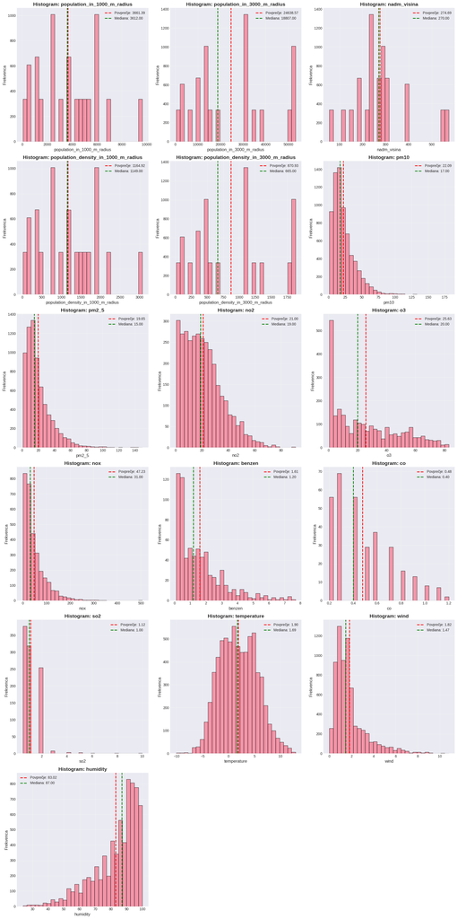

```
Boxploti shranjeni v plots/boxplots.png
```

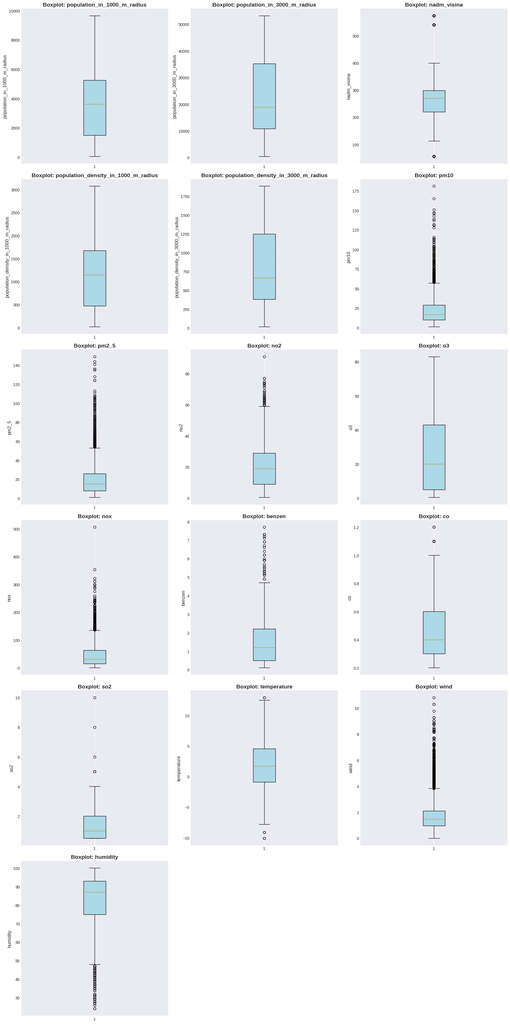

```
3. grafi za kategorije spremenljivke
--------------------------------------------------------------------------------

Analiza kategorijskih spremenljivk:
Analiziram kategorijsko spremenljivko: nadm_visina_kategorija

nadm_visina_kategorija:
  - N: 6992, Manjkajoče: 0
  - Število kategorij: 3
  - Porazdelitev:
    • srednja: 4031 (57.7%)
    • nizka: 1680 (24.0%)
    • visoka: 1281 (18.3%)
Analiziram kategorijsko spremenljivko: population_density_in_1000_m_radius_kategorija

population_density_in_1000_m_radius_kategorija:
  - N: 6992, Manjkajoče: 0
  - Število kategorij: 3
  - Porazdelitev:
    • visoka urbanost: 2688 (38.4%)
    • srednja urbanost: 2351 (33.6%)
    • nizka urbanost: 1953 (27.9%)
Analiziram kategorijsko spremenljivko: population_density_in_3000_m_radius_kategorija

population_density_in_3000_m_radius_kategorija:
  - N: 6992, Manjkajoče: 0
  - Število kategorij: 3
  - Porazdelitev:
    • nizka urbanost: 2961 (42.3%)
    • srednja urbanost: 2687 (38.4%)
    • visoka urbanost: 1344 (19.2%)
Analiziram kategorijsko spremenljivko: pm2.5_nezravo

pm2.5_nezravo:
  - N: 6992, Manjkajoče: 0
  - Število kategorij: 2
  - Porazdelitev:
    • 0: 5068 (72.5%)
    • 1: 1924 (27.5%)

Tabela kategorijskih spremenljivk shranjena v plots/categorical_stats.csv
Barploti shranjeni v plots/barplots.png
```

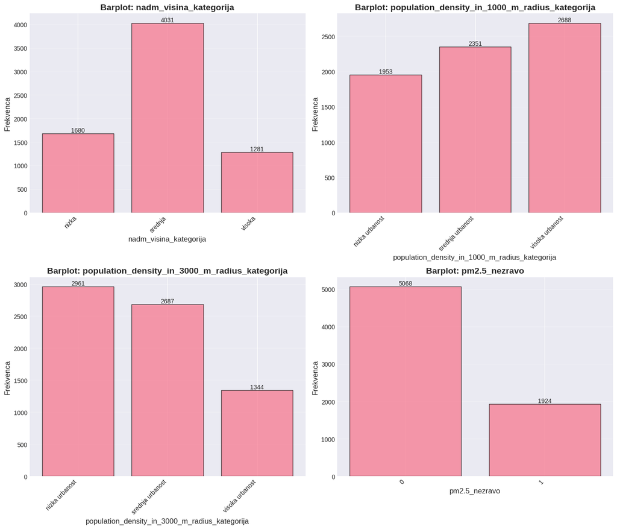

```
4. interpretacija
--------------------------------------------------------------------------------

Opažanja in interpretacija:


population_in_1000_m_radius:
  - Število opazovanj: 6992 (manjkajoče: 0)
  - 3612.00 (1490.00–5252.00)
  - Razpon: 52.00 - 9652.00
  - Porazdelitev: Nenormalna - uporabljena mediana namesto povprečja

population_in_3000_m_radius:
  - Število opazovanj: 6992 (manjkajoče: 0)
  - 18807.00 (10792.00–35257.00)
  - Razpon: 406.00 - 53199.00
  - Porazdelitev: Nenormalna - uporabljena mediana namesto povprečja

nadm_visina:
  - Število opazovanj: 6992 (manjkajoče: 0)
  - 270.00 (220.00–299.00)
  - Razpon: 56.00 - 574.00
  - Opozorilo: 1008 možnih odstopanj (outliers) identificiranih
  - Porazdelitev: Nenormalna - uporabljena mediana namesto povprečja

population_density_in_1000_m_radius:
  - Število opazovanj: 6992 (manjkajoče: 0)
  - 1149.00 (474.00–1671.00)
  - Razpon: 16.00 - 3072.00
  - Porazdelitev: Nenormalna - uporabljena mediana namesto povprečja

population_density_in_3000_m_radius:
  - Število opazovanj: 6992 (manjkajoče: 0)
  - 665.00 (381.00–1246.00)
  - Razpon: 14.00 - 1881.00
  - Porazdelitev: Nenormalna - uporabljena mediana namesto povprečja

pm10:
  - Število opazovanj: 6992 (manjkajoče: 0)
  - 17.00 (10.00–29.00)
```

[output cut: 57 more lines]

```
  - Porazdelitev: Nenormalna - uporabljena mediana namesto povprečja

wind:
  - Število opazovanj: 6992 (manjkajoče: 0)
  - 1.47 (0.96–2.11)
  - Razpon: 0.00 - 10.80
  - Opozorilo: 654 možnih odstopanj (outliers) identificiranih
  - Porazdelitev: Nenormalna - uporabljena mediana namesto povprečja

humidity:
  - Število opazovanj: 6992 (manjkajoče: 0)
  - 87.00 (75.00–93.00)
  - Razpon: 24.00 - 100.00
  - Opozorilo: 173 možnih odstopanj (outliers) identificiranih
  - Porazdelitev: Nenormalna - uporabljena mediana namesto povprečja
```

```python
from descriptive_stats import create_descriptive_report, calculate_descriptive_stats
from xmReader import get_stations
from data_cleaning import data_cleaning
import pandas as pd
from xmReader import get_stations, get_station_stats, get_features, save_stations_to_xml
from data_cleaning import data_cleaning

from xmReader import *
from data_cleaning import *
from population import *


all_stations = cleaned_stations_newYear + cleaned_stations_december

stats_table, df = create_descriptive_report(all_stations, output_dir='plots')
```

## Bivariatna analiza

Odvisna spremenljivka Y - PM2.5

### Numericne spremenljivke

```python
# Spearmanov korelacijski test med PM2.5 in neodvisnimi spremenljivkami
import pandas as pd
import numpy as np
from scipy.stats import spearmanr

# odvisne in neodvisne spremenljivke
y = df['pm2_5']
neodvisne = [
    'no2', 'nox', 'o3', 'co', 'so2', 'benzen',
    'nadm_visina',
    'population_density_in_1000_m_radius',
    'population_density_in_3000_m_radius',
    'ura_od', 'temperature', 'wind', 'humidity'
]

print("Spearmanove korelacije (PM2.5 ~ X):")
korelacije = []
for x in neodvisne:
    # Odstrani primere s manjkajočimi vrednostmi
    valid = df[['pm2_5', x]].dropna()
    if len(valid) > 2:
        coef, pval = spearmanr(valid['pm2_5'], valid[x])
        print(f"{x:40s} : r = {coef:6.3f}   (p = {pval:.4f})")
        korelacije.append({'spremenljivka': x, 'spearman_r': coef, 'p-vrednost': pval})
    else:
        print(f"{x:40s} : premalo podatkov")

spearman_df = pd.DataFrame(korelacije)
```

[output not shown]

```
Benzen (μg/m³)                           : r =  0.917   (p = 0.0000)
CO (mg/m³)                               : r =  0.798   (p = 0.0000)
O₃ (μg/m³)                               : r = -0.717   (p = 0.0000)
NO₂ (μg/m³)                              : r =  0.535   (p = 0.0000)
NOx (μg/m³)                              : r =  0.470   (p = 0.0000)
Nadmorska višina (m)                     : r = -0.090   (p = 0.0000)
Gostota populacije (1000m) (prebivalci/km²) : r =  0.041   (p = 0.0005)
Gostota populacije (3000m) (prebivalci/km²) : r =  0.044   (p = 0.0003)
Temperatura (°C)                         : r = -0.377   (p = 0.0000)
hitrost vetra (m/s)                      : r = -0.267   (p = 0.0000)
vlažnost (%)                             : r = -0.003   (p = 0.8309)
Scatter ploti shranjeni v plots/scatter_plots.png
```

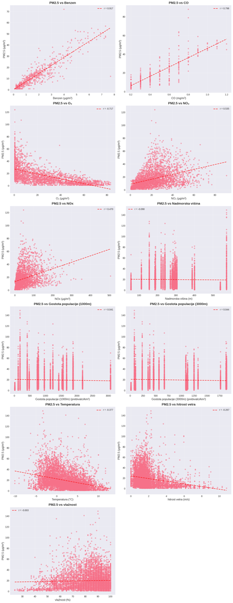

```python
import matplotlib.pyplot as plt
import numpy as np
from scipy.stats import spearmanr

# scatter ploti
scatter_vars = [
    ('benzen', 'Benzen (μg/m³)', 'PM2.5 vs Benzen'),
    ('co', 'CO (mg/m³)', 'PM2.5 vs CO'),
    ('o3', 'O₃ (μg/m³)', 'PM2.5 vs O₃'),
    ('no2', 'NO₂ (μg/m³)', 'PM2.5 vs NO₂'),
    ('nox', 'NOx (μg/m³)', 'PM2.5 vs NOx'),
    ('nadm_visina', 'Nadmorska višina (m)', 'PM2.5 vs Nadmorska višina'),
    ('population_density_in_1000_m_radius', 'Gostota populacije (1000m) (prebivalci/km²)', 'PM2.5 vs Gostota populacije (1000m)'),
    ('population_density_in_3000_m_radius', 'Gostota populacije (3000m) (prebivalci/km²)', 'PM2.5 vs Gostota populacije (3000m)'),
    ('temperature', 'Temperatura (°C)', 'PM2.5 vs Temperatura'),
    ('wind', 'hitrost vetra (m/s)', 'PM2.5 vs hitrost vetra'),
    ('humidity', 'vlažnost (%)', 'PM2.5 vs vlažnost'),

]

# st vrst in stolpcev
n_vars = len(scatter_vars)
n_cols = 2
n_rows = (n_vars + n_cols - 1) // n_cols

# Ustvari subplot grid
fig, axes = plt.subplots(n_rows, n_cols, figsize=(14, 6*n_rows))
axes = axes.flatten()

for idx, (var, xlabel, title) in enumerate(scatter_vars):
    ax = axes[idx]

    # Odstrani manjkajoče vrednosti
    valid = df[['pm2_5', var]].dropna()

    if len(valid) > 2:
        ax.scatter(valid[var], valid['pm2_5'], alpha=0.5, s=20)

        # Spearmanova korelacija
        coef, pval = spearmanr(valid[var], valid['pm2_5'])
        print(f"{xlabel:40s} : r = {coef:6.3f}   (p = {pval:.4f})")

        # trendna črta
        z = np.polyfit(valid[var], valid['pm2_5'], 1)
        p = np.poly1d(z)
        x_line = np.linspace(valid[var].min(), valid[var].max(), 100)
        ax.plot(x_line, p(x_line), "r--", alpha=0.8, linewidth=2, label=f'r = {coef:.3f}')

        ax.set_xlabel(xlabel, fontsize=12)
        ax.set_ylabel('PM2.5 (μg/m³)', fontsize=12)
        ax.set_title(title, fontsize=14, fontweight='bold')
        ax.legend(loc='best')
        ax.grid(True, alpha=0.3)
    else:
        ax.text(0.5, 0.5, 'Premalo podatkov', ha='center', va='center', transform=ax.transAxes)
        ax.set_title(title, fontsize=14, fontweight='bold')

# skrivanje neuporabljenih subplotov
for idx in range(n_vars, len(axes)):
    axes[idx].axis('off')

plt.tight_layout()

import os
os.makedirs('plots', exist_ok=True)
plt.savefig('plots/scatter_plots.png', dpi=300, bbox_inches='tight')
print("Scatter ploti shranjeni v plots/scatter_plots.png")

plt.show()
plt.close()
```

## Interpretacija Spearmanovih korelacij

- Benzen (r = 0.917, p < 0.0001)

Zelo močna pozitivna povezava. Benzen in PM2.5 se pogosto pojavljata skupaj, kar kaže na skupne vire onesnaženja (promet, industrija).

- CO (r = 0.798, p < 0.0001)

Zelo močna pozitivna povezava. Ogljikov monoksid in PM2.5 imata skupne vire (predvsem promet, kurjenje).

- O3 (r = -0.717, p < 0.0001)

Močna negativna povezava. Ozon in PM2.5 sta pogosto v inverzni povezavi - ko je ozon visok (sončno vreme, poletje), so delci običajno nižji.

#### Zmerne pozitivne korelacije (0.4 < r < 0.7):

- NO2 (r = 0.535, p < 0.0001)

Zmerna do močna pozitivna povezava. Dušikov dioksid in PM2.5 imata skupne vire (promet, kurjenje).

- NOx (r = 0.470, p < 0.0001)

Zmerna pozitivna povezava. Dušikovi oksidi so povezani s PM2.5.

- Temperatura (r = -0.377, p < 0.0001)

Šibka do zmerna negativna povezava, vendar statistično značilna. Višje temperature so povezane z boljšim mešanjem zraka in večjo razpršitvijo delcev, kar vodi do nižjih koncentracij PM2.5.

- Hitrost vetra (r = -0.267, p < 0.0001)

Šibka negativna povezava, vendar statistično značilna. Povečana hitrost vetra izboljšuje prezračevanje in razredčevanje zraka, kar je potrditev z opazovanim zmanjšanjem koncentracij PM2.5 pri večjih hitrostih vetra.

Šibka negativna povezava, vendar statistično značilna.

- Nadmorska višina (r = -0.090, p < 0.0001)

Šibka negativna povezava -višje ležeče postaje imajo nekoliko nižje koncentracije PM2.5, kar je pričakovano zaradi boljšega prezračevanja in manjše lokalne emisijske obremenitve.

- Gostota populacije (1000m) (r = 0.041, p = 0.0005)
- Gostota populacije (3000m) (r = 0.044, p = 0.0003)

Gostota je statistično značilna a sta korelaciji zelo majhni. Rezultati kažejo, da sama gostota prebivalstva ni neposreden napovedovalec PM2.5 brez upoštevanja lokalnih virov emisij.

Šibka pozitivna povezava - določene ure dneva so povezane z višjimi PM2.5 vrednostmi.

#### Statistično neznačilne korelacije (p > 0.05):

- Vlažnost (r = -0.003, p = 0.8309)

Ni zaznane linearne povezave med vlažnostjo in PM2.5. To nakazuje, da vpliv vlažnosti na koncentracije delcev ni povezano.

**Zaključki:**

1. **Najmočnejši napovedovalci PM2.5** so benzen in CO, kar kaže na pomembnost prometnih in industrijskih virov.
2. **Ozon** kaže močno negativno povezavo, kar je značilno za različne meteorološke pogoje.
3. **Meteorološki dejavniki** (temperatura in hitrost vetra) imajo šibkejši, a fizikalno razumljiv vpliv na koncentracije PM2.5 in bodo verjetno pomembni v multivariatnih modelih.
4. **Gostota populacije** ne kaže pomembne povezave z PM2.5, kar lahko pomeni, da je onesnaženje bolj odvisno od lokalnih virov kot od gostote prebivalstva.
5. **Nadmorska višina** ima šibko negativno povezavo, kar je pričakovano (višje postaje imajo običajno nižje koncentracije delcev).

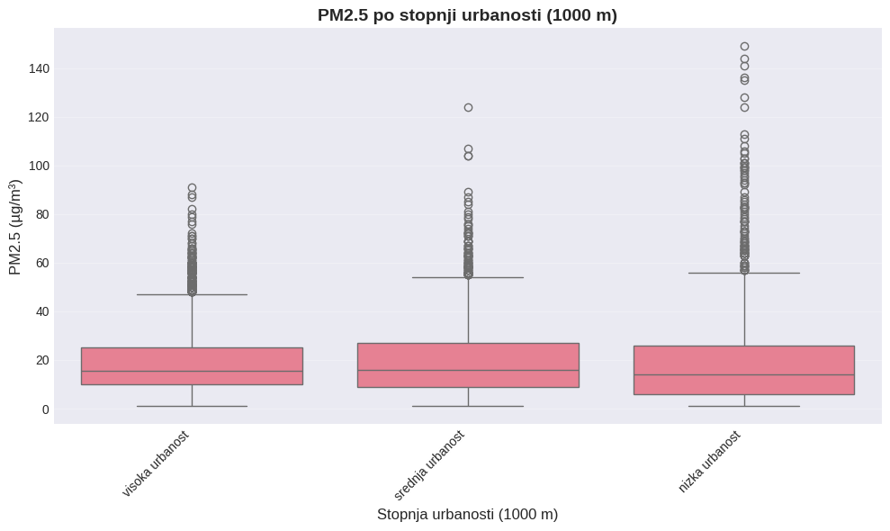

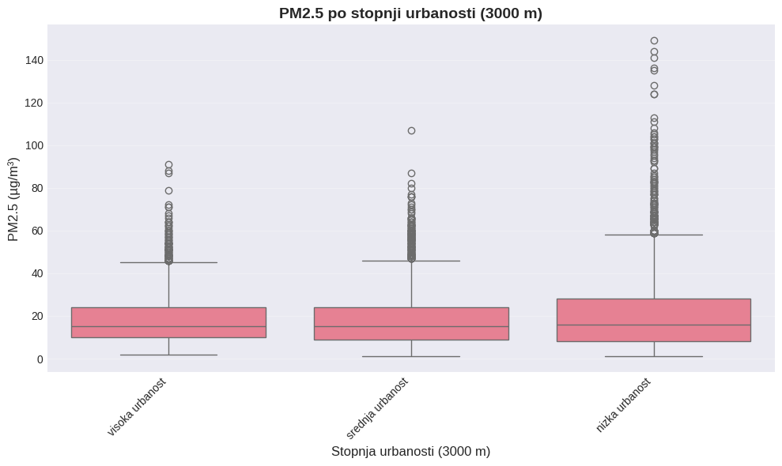

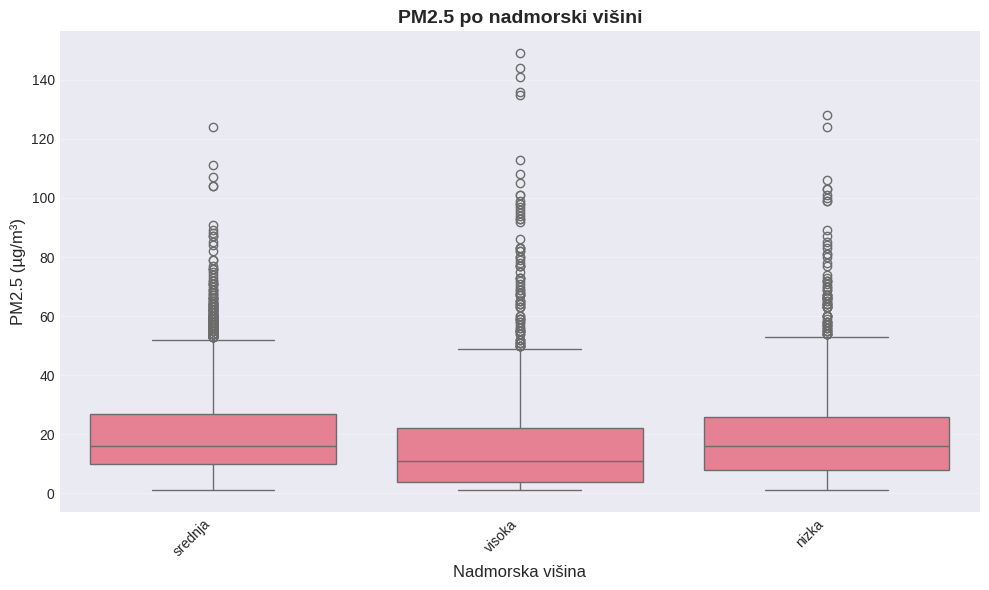

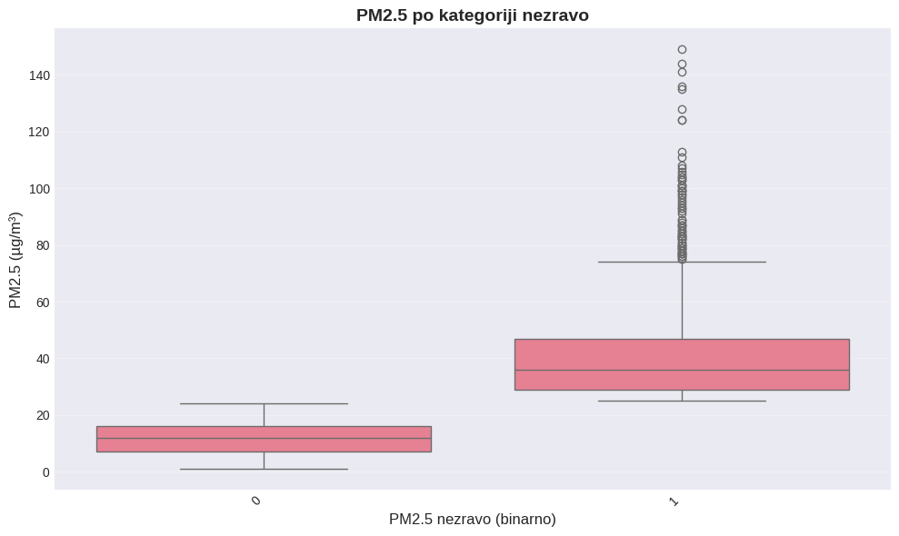

```
Kruskal-Wallis testi za vse kategorijske spremenljivke:

population_density_in_1000_m_radius_kategorija:
  H-statistika = 44.151
  p-vrednost = 0.0000
 Statistično značilna razlika med skupinami

population_density_in_3000_m_radius_kategorija:
  H-statistika = 2.990
  p-vrednost = 0.2243
 Ni statistično značilne razlike med skupinami

nadm_visina_kategorija:
  H-statistika = 185.705
  p-vrednost = 0.0000
 Statistično značilna razlika med skupinami

pm2.5_nezravo:
  H-statistika = 4186.574
  p-vrednost = 0.0000
 Statistično značilna razlika med skupinami
```

```python
import seaborn as sns
from scipy.stats import kruskal
import matplotlib.pyplot as plt
import os

# kategorijske spremenljivke
categorical_vars = [
    ('population_density_in_1000_m_radius_kategorija', 'Stopnja urbanosti (1000 m)', 'PM2.5 po stopnji urbanosti (1000 m)'),
    ('population_density_in_3000_m_radius_kategorija', 'Stopnja urbanosti (3000 m)', 'PM2.5 po stopnji urbanosti (3000 m)'),
    ('nadm_visina_kategorija', 'Nadmorska višina', 'PM2.5 po nadmorski višini'),
    ('pm2.5_nezravo', 'PM2.5 nezravo (binarno)', 'PM2.5 po kategoriji nezravo')
]

y_var = 'pm2_5'

os.makedirs('plots', exist_ok=True)

stats = []

#
for cat_var, xlabel, title in categorical_vars:
    valid = df[[cat_var, y_var]].dropna()

    if len(valid) == 0:
        print(f"Ni podatkov za {cat_var}")
        continue

    # preveri kolicino kategorij
    unique_cats = valid[cat_var].unique()
    if len(unique_cats) < 2:
        print(f"Premalo kategorij za {cat_var} (najdeno: {len(unique_cats)})")
        continue

    # Boxplot
    plt.figure(figsize=(10, 6))
    sns.boxplot(data=valid, x=cat_var, y=y_var)
    plt.xlabel(xlabel, fontsize=12)
    plt.ylabel('PM2.5 (µg/m³)', fontsize=12)
    plt.title(title, fontsize=14, fontweight='bold')
    plt.grid(axis='y', alpha=0.3)
    plt.xticks(rotation=45, ha='right')
    plt.tight_layout()

    safe_filename = cat_var.replace('.', '_').replace(' ', '_')
    plt.savefig(f'plots/boxplot_{safe_filename}.png', dpi=300, bbox_inches='tight')

    plt.show()
    plt.close()

    # Kruskal-Wallis test
    try:
        groups = [g[y_var].values for _, g in valid.groupby(cat_var) if len(g) > 0]

        if len(groups) < 2:
            print(f"Premalo skupin za Kruskal-Wallis test ({len(groups)} skupin)")
            continue

        # Odstrani prazne skupine
        groups = [g for g in groups if len(g) > 0]

        if len(groups) < 2:
            print(f"Premalo skupin z podatki za Kruskal-Wallis test")
            continue

        stat, pval = kruskal(*groups)

        stats.append({'spremenljivka': cat_var, 'H-statistika': stat, 'p-vrednost': pval})

    except Exception as e:
        print(f"Napaka pri izvajanju Kruskal-Wallis testa: {e}")

# Povzetek vseh rezultatov
if len(stats) > 0:
    print("Kruskal-Wallis testi za vse kategorijske spremenljivke:")
    for result in stats:
        print(f"\n{result['spremenljivka']}:")
        print(f"  H-statistika = {result['H-statistika']:.3f}")
        print(f"  p-vrednost = {result['p-vrednost']:.4f}")
        if result['p-vrednost'] < 0.05:
            print(f" Statistično značilna razlika med skupinami")
        else:
            print(f" Ni statistično značilne razlike med skupinami")
```

#### **Stopnja urbanosti v 1000-metrskem radiju**

Rezultati kažejo statistično značilne razlike v koncentracijah PM2.5 med različnimi stopnjami urbanosti v neposredni okolici merilnih postaj (H = 44.151, p < 0.001). To pove, da lokalna urbanizacija in z njo povezani viri emisij (promet), pomembno vplivajo na koncentracije delcev PM2.5.

#### **Stopnja urbanosti v 3000-metrskem radiju**

Za širše območje statistično značilnih razlik v koncentracijah PM2.5 med kategorijami urbanosti nisva zaznala (H = 2.990, p = 0.2243). Rezultat kaže, da širša urbanizacija nima neposrednega vpliva na koncentracije PM2.5, temveč so ti predvsem odvisni od lokalnih virov onesnaženja.

#### **Kategorije nadmorske višine**

Analiza je pokazala zelo izrazite statistično značilne razlike v koncentracijah PM2.5 med različnimi kategorijami nadmorske višine (H = 185.705, p < 0.001). Nižje ležeče postaje izkazujejo višje koncentracije PM2.5.

#### **Binarna spremenljivka PM2.5 nezdravo**

Kruskal–Wallisov test je pokazal statistično značilne razlike v koncentracijah PM2.5 med kategorijama zdrave in nezdrave kakovosti zraka (H = 4186.574, p < 0.001). Rezultat je pričakovan, saj je binarna spremenljivka neposredno definirana na podlagi koncentracij PM2.5.

[output not shown]

## 1.5 Izbor spremenljivk

Spremenljivke benzen, CO, SO₂ in delno NOx niso bile vključene v osnovni model zaradi velikega deleža manjkajočih vrednosti, kljub močni korelacijski povezanosti z odvisno spremenljivko.

```python
# Analiza manjkajočih vrednosti v X
X = df[[
    'no2', 'nox', 'co', 'benzen',
    'o3', 'nadm_visina',
    'population_density_in_1000_m_radius',
    'ura_od'
]]

print("Analiza manjkajočih vrednosti po vrsticah:")

rows_with_missing = 0
for idx, row in X.iterrows():
    missing_cols = row[row.isna()].index.tolist()
    if len(missing_cols) > 0:
        rows_with_missing += 1
    # else:
        # print(f"Vrstica {idx}: {row.to_dict()}")


print(f"\nSkupno število vrstic z manjkajočimi vrednostmi: {rows_with_missing} od {len(X)}")
print(f"Število vrstic brez manjkajočih vrednosti: {len(X) - rows_with_missing}")

print(f"\nManjkajoče vrednosti po stolpcih:")
print(X.isna().sum())
```

```
Analiza manjkajočih vrednosti po vrsticah:

Skupno število vrstic z manjkajočimi vrednostmi: 6949 od 6992
Število vrstic brez manjkajočih vrednosti: 43

Manjkajoče vrednosti po stolpcih:
no2                                    3650
nox                                    3939
co                                     6670
benzen                                 6279
o3                                     4434
nadm_visina                               0
population_density_in_1000_m_radius       0
ura_od                                    0
dtype: int64
```

```python
df['ura_od_num'] = pd.to_datetime(df['ura_od'], format='%H:%M').dt.hour

X = df[[
    'temperature',
    'wind',
    'humidity',
    'nadm_visina',
    'population_density_in_1000_m_radius',
    'ura_od_num'
]]


y = df['pm2_5']

X_clean = X.dropna()
y_clean = y.loc[X_clean.index]

print(f"Število vrstic: {len(X_clean)}")
```

```
Število vrstic: 6992
```

```python
from sklearn.ensemble import RandomForestRegressor

rf = RandomForestRegressor(
    n_estimators=300,
    max_depth=8,
    random_state=42
)

rf.fit(X_clean, y_clean)

importances = (
    pd.Series(rf.feature_importances_, index=X_clean.columns)
    .sort_values(ascending=False)
)

importances
```

```
temperature                            0.302868
ura_od_num                             0.165881
nadm_visina                            0.158992
population_density_in_1000_m_radius    0.138442
wind                                   0.129980
humidity                               0.103838
dtype: float64
```

| Spremenljivka | Pomembnost | Interpretacija |
| --- | --- | --- |
| Temperatura | 0.303 | Najpomembnejša spremenljivka. Nižje temperature so pogosto povezane z večjim onesnaženjem zaradi temperaturnih inverzij, povečane rabe ogrevanja in slabšega mešanja zraka. |
| Ura dneva | 0.166 | Pomemben časovni dejavnik, ki odraža dnevne vzorce prometa in človekovih aktivnosti (jutranje in popoldanske prometne konice). |
| Nadmorska višina | 0.159 | Višje ležeče postaje imajo praviloma boljše prezračevanje in nižje koncentracije delcev PM2.5. |

[output not shown]

## 2.1 - Priprava podatkov za modeliranje

Podatki so časovno odvisni, zato je deljenje na učno in testno množico bilo na podlagi njihovih datumov. Prvih 80 % meritev je bilo uporabljenih kot učna množica, zadnjih 20 % pa kot testna množica.

Pred modeliranjem so bile izbrane spremenljivke združene v enoten nabor podatkov, manjkajoče vrednosti pa so bile odstranjene.

Za modele, občutljive na skalo spremenljivk (npr. linearna regresija, LASSO, SVR),, je bila izvedena standardizacija na podlagi učne množice. (https://scikit-learn.org/stable/modules/preprocessing.html#standardization-or-mean-removal-and-variance-scaling)

```python
# Sortiranje po datumu
df['datetime'] = pd.to_datetime(df['datum_od'])
df = df.sort_values('datetime')

features = [
    'temperature',
    'wind',
    'humidity',
    'nadm_visina',
    'population_density_in_1000_m_radius',
    'ura_od_num'
]

X_model = df[features]
y_model = df['pm2_5']

#  izloči NaN vrednosti
data = pd.concat([X_model, y_model], axis=1).dropna()

X_clean = data[features]
y_clean = data['pm2_5']


# razdeli na učno in testno množico
split_idx = int(len(data) * 0.8)

X_train_model = X_clean.iloc[:split_idx]
X_test_model  = X_clean.iloc[split_idx:]

y_train_model = y_clean.iloc[:split_idx]
y_test_model  = y_clean.iloc[split_idx:]

print("Učna množica:", X_train_model.shape)
print("Testna množica:", X_test_model.shape)
```

```
Učna množica: (5593, 6)
Testna množica: (1399, 6)
```

```python
from sklearn.preprocessing import StandardScaler

# standardizacija vrednosti
scaler = StandardScaler()
X_train_scaled = scaler.fit_transform(X_train_model)
X_test_scaled  = scaler.transform(X_test_model)
```

## 2.2 Gradnja modelov

```python
from sklearn.linear_model import LinearRegression, Lasso, Ridge, ElasticNet
from sklearn.ensemble import RandomForestRegressor, GradientBoostingRegressor
from sklearn.svm import SVR
from xgboost import XGBRegressor

models = {
    'LinearRegression' : {
        'model': LinearRegression(),
        'params': {},
        'use_scaled': True
    },
    'Lasso': {
        'model': Lasso(alpha=0.05, max_iter=5000, random_state=42),
        'params': {
            'alpha': [0.001, 0.005, 0.01, 0.05, 0.1, 0.5, 1.0],
            'selection': ['cyclic', 'random'],
            'max_iter': [5000, 10000]
        },
        'use_scaled': True
    },
    'RandomForestRegressor': {
        'model': RandomForestRegressor(n_estimators=300, max_depth=8, min_samples_leaf=10, random_state=42),
        'params': {
            'max_features': ['sqrt', 0.7],
            'max_depth': [6, 10, None],
            'min_samples_leaf': [5, 10, 20]
        },
        'use_scaled': False
    },
    'GradientBoostingRegressor': {
        'model': GradientBoostingRegressor(n_estimators=200, learning_rate=0.05, max_depth=3, random_state=42),
        'params': {
            'n_estimators': [150, 300],
            'learning_rate': [0.03, 0.1],
            'max_depth': [2, 3]
        },
        'use_scaled': False
    },
    'SVR': {
        'model': SVR(C=10, epsilon=0.1, kernel='rbf'),
        'params': {
            'C': [5, 10, 50],
            'epsilon': [0.05, 0.1],
            'gamma': ['scale', 0.1]
        },
        'use_scaled': True
    },
    'XGBoost': {
        'model': XGBRegressor(
        objective='reg:squarederror',
        n_estimators=300,
        learning_rate=0.05,
        max_depth=4,
        subsample=0.8,
        colsample_bytree=0.8,
        random_state=42
    ),
    'params': {
        'n_estimators': [200, 400],
        'learning_rate': [0.03, 0.1],
        'max_depth': [3, 5],
        'subsample': [0.7, 0.9],
        'colsample_bytree': [0.7, 1.0]
    },
    'use_scaled': False
    }
}

def make_model(model_name, params):
    if model_name == 'LinearRegression':
        return LinearRegression(**params)

    elif model_name == 'Lasso':
        return Lasso(
            random_state=42,
            **params
        )

    elif model_name == 'RandomForestRegressor':
        return RandomForestRegressor(
            n_estimators=300,
            random_state=42,
            **params
        )

    elif model_name == 'GradientBoostingRegressor':
        return GradientBoostingRegressor(
            random_state=42,
            **params
        )

    elif model_name == 'SVR':
        return SVR(**params)

    elif model_name == 'XGBoost':
        return XGBRegressor(
            objective='reg:squarederror',
            **params
        )
```

```python
from sklearn.model_selection import KFold

cv = KFold(
    n_splits=10,
    shuffle=True,
    random_state=42
)

from sklearn.metrics import make_scorer, mean_squared_error, mean_absolute_error
import numpy as np

rmse_scorer = make_scorer(
    lambda y, y_pred: np.sqrt(mean_squared_error(y, y_pred)),
    greater_is_better=False
)
```

```python
from sklearn.model_selection import cross_validate
from itertools import product

results = []

# Zazeni modele in evaluacija, traja okoli 7 min
def test_models():
    for model_name, cfg in models.items():
        param_grid = cfg['params']
        use_scaled = cfg['use_scaled']

        print(f"Evaluating {model_name} with scaled data: {use_scaled}")
        if param_grid:
            keys, values = zip(*param_grid.items())
            param_combinations = [dict(zip(keys, v)) for v in product(*values)]
        else:
            param_combinations = [{}]

        for params in param_combinations:
            model = make_model(model_name, params)

            X_used = X_train_scaled if use_scaled else X_train_model

            scores = cross_validate(
                model,
                X_used,
                y_train_model,
                cv=cv,
                scoring={
                    'r2': 'r2',
                    'rmse': rmse_scorer,
                    'mae': 'neg_mean_absolute_error'
                }
            )

            results.append({
                'model': model_name,
                'params': params,
                'R2_mean': scores['test_r2'].mean(),
                'RMSE_mean': -scores['test_rmse'].mean(),
                'MAE_mean': -scores['test_mae'].mean()
            })

# test_models()
```

```python
results_df = pd.DataFrame(results)
print(results_df)
```

```
Empty DataFrame
Columns: []
Index: []
```

```python
# Shrani rezultate v csv
# results_df.to_csv("model_results_xgboost.csv", index=False)

results_df = pd.read_csv("files/csvs/model_results.csv")
# Combine results_df with results_df_final
# combined_results = pd.concat([results_df, results_df_final], ignore_index=True)
# print(combined_results.head())

# results_df.to_csv("model_results_cv2.csv", index=False)

def select_top_models(
    df,
    metric='R2_mean',
    n_models=3,
    ascending=False
):
    return (
        df
        .sort_values(metric, ascending=ascending)
        .head(n_models)
        .reset_index(drop=True)
    )

def select_top_models_multi(df, n_models=3):
    df_sorted = df.copy()

    df_sorted['rank_r2'] = df_sorted['R2_mean'].rank(ascending=False)
    df_sorted['rank_rmse'] = df_sorted['RMSE_mean'].rank(ascending=True)

    df_sorted['rank_total'] = df_sorted['rank_r2'] + df_sorted['rank_rmse']

    return (
        df_sorted
        .sort_values('rank_total')
        .head(n_models)
        .reset_index(drop=True)
    )

selected_models = select_top_models(results_df, metric='R2_mean', n_models=3, ascending=False)
selected_models2 = select_top_models_multi(results_df, n_models=3)

print(selected_models)
print(selected_models2)
```

```
     model                                             params   R2_mean  \
0  XGBoost  {'n_estimators': 400, 'learning_rate': 0.1, 'm...  0.700642
1  XGBoost  {'n_estimators': 400, 'learning_rate': 0.1, 'm...  0.694746
2  XGBoost  {'n_estimators': 400, 'learning_rate': 0.1, 'm...  0.692072

   RMSE_mean  MAE_mean
0   8.531358  5.710106
1   8.612448  5.767482
2   8.654111  5.813393
     model                                             params   R2_mean  \
0  XGBoost  {'n_estimators': 400, 'learning_rate': 0.1, 'm...  0.700642
1  XGBoost  {'n_estimators': 400, 'learning_rate': 0.1, 'm...  0.694746
2  XGBoost  {'n_estimators': 400, 'learning_rate': 0.1, 'm...  0.692072

   RMSE_mean  MAE_mean  rank_r2  rank_rmse  rank_total
0   8.531358  5.710106      1.0        1.0         2.0
1   8.612448  5.767482      2.0        2.0         4.0
2   8.654111  5.813393      3.0        3.0         6.0
```

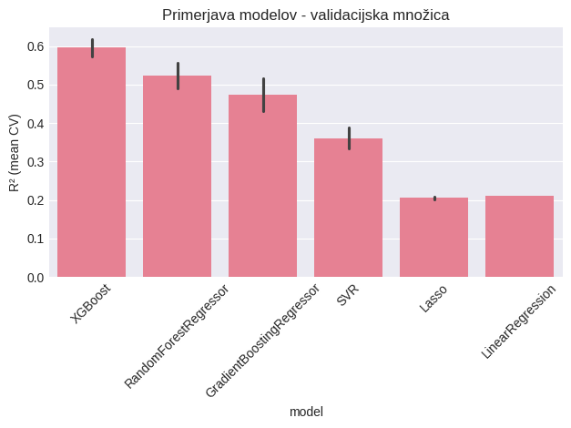

```python
import seaborn as sns
import matplotlib.pyplot as plt

sns.barplot(data=results_df, x='model', y='R2_mean')
plt.xticks(rotation=45)
plt.ylabel("R² (mean CV)")
plt.title("Primerjava modelov - validacijska množica")
plt.tight_layout()
plt.show()
```

[output not shown]

## 3. Izbor najboljših modelov in testiranje

Na podlagi rezultatov 10-kratne navzkrižne validacije (10-fold cross-validation) sva izbrala tri najboljše regresijske modele glede na kombinacijo napovedne natančnosti (R², RMSE, MAE) in stabilnosti rezultatov.

Izbrani modeli so bili nato ponovno naučeni na celotni učni množici (80 % podatkov), nato pa ovrednoteni na neodvisni testni množici (20 % podatkov), ki časovno sledi učnim podatkom.

Za vsak model smo izračunali naslednje metrike:

- koeficient determinacije (R²),
- koren srednje kvadratne napake (RMSE),
- srednjo absolutno napako (MAE),
- povprečno absolutno odstotno napako (MAPE).

Rezultati so predstavljeni tabelarično in grafično, kar omogoča neposredno primerjavo napovedne uspešnosti modelov.

```python
import numpy as np
import pandas as pd
from sklearn.metrics import r2_score, mean_squared_error, mean_absolute_error
from sklearn.ensemble import RandomForestRegressor, GradientBoostingRegressor
from xgboost import XGBRegressor
import joblib

# features and target (same as point 2)
features = [
    "temperature",
    "wind",
    "humidity",
    "nadm_visina",
    "population_density_in_1000_m_radius",
    "ura_od_num",
]

target = "pm2_5"

# sort by time and split 80/20
df_p3 = df.sort_values("datum_od").dropna(subset=[target])

X_model = df_p3[features]
y_model = df_p3[target]

split_idx = int(len(df_p3) * 0.8)

X_train_model = X_model.iloc[:split_idx]
X_test_model = X_model.iloc[split_idx:]
y_train_model = y_model.iloc[:split_idx]
y_test_model = y_model.iloc[split_idx:]

print("Train:", X_train_model.shape, "Test:", X_test_model.shape)

def mape(y_true, y_pred):
    y_true = np.array(y_true)
    y_pred = np.array(y_pred)
    return np.mean(np.abs((y_true - y_pred) / np.maximum(y_true, 1e-9))) * 100

models = {
    "XGBoost": XGBRegressor(
        n_estimators=400,
        max_depth=5,
        learning_rate=0.05,
        subsample=0.8,
        colsample_bytree=0.8,
        random_state=42,
        n_jobs=-1,
    ),
    "RandomForest": RandomForestRegressor(
        n_estimators=500,
        random_state=42,
        n_jobs=-1,
    ),
    "GradientBoosting": GradientBoostingRegressor(
        n_estimators=500,
        learning_rate=0.05,
        max_depth=3,
        random_state=42,
    ),
}

results = []
predictions = {}

for name, model in models.items():
    model.fit(X_train_model, y_train_model)
    y_pred = model.predict(X_test_model)

    results.append({
        "Model": name,
        "R2": r2_score(y_test_model, y_pred),
        "RMSE": np.sqrt(mean_squared_error(y_test_model, y_pred)),
        "MAE": mean_absolute_error(y_test_model, y_pred),
        "MAPE": mape(y_test_model, y_pred),
    })

    predictions[name] = y_pred
    joblib.dump(model, f"final_model_{name}.joblib")

results_test = pd.DataFrame(results).sort_values("RMSE")
results_test
```

```
Train: (5593, 6) Test: (1399, 6)
```

|  | Model | R2 | RMSE | MAE | MAPE |
| --- | --- | --- | --- | --- | --- |
| 2 | GradientBoosting | 0.345648 | 14.667939 | 9.834653 | 89.019678 |
| 0 | XGBoost | 0.321676 | 14.934205 | 9.758423 | 91.300142 |
| 1 | RandomForest | 0.310212 | 15.059870 | 10.079346 | 96.872302 |

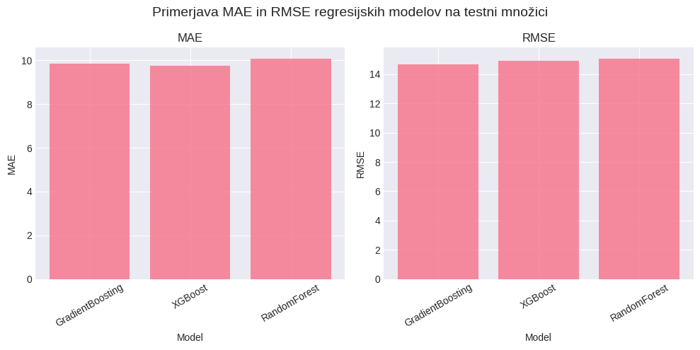

```python
fig, axes = plt.subplots(1, 2, figsize=(10, 5))
axes = axes.flatten()

# ensure correct order
results_plot = results_test.copy()
results_plot = results_plot.sort_values("RMSE")

metrics = ["MAE", "RMSE"]

for ax, metric in zip(axes, metrics):
    ax.bar(
        results_plot["Model"],
        results_plot[metric],
        alpha=0.8
    )
    ax.set_title(metric)
    ax.set_xlabel("Model")
    ax.set_ylabel(metric)
    ax.tick_params(axis="x", rotation=30)

plt.suptitle("Primerjava MAE in RMSE regresijskih modelov na testni množici", fontsize=14)
plt.tight_layout()
plt.show()
```

```
Model: XGBoost
  R²   = 0.3217
  RMSE = 14.9342
  MAE  = 9.7584
------------------------------
Model: RandomForest
  R²   = 0.3102
  RMSE = 15.0599
  MAE  = 10.0793
------------------------------
Model: GradientBoosting
  R²   = 0.3456
  RMSE = 14.6679
  MAE  = 9.8347
------------------------------
```

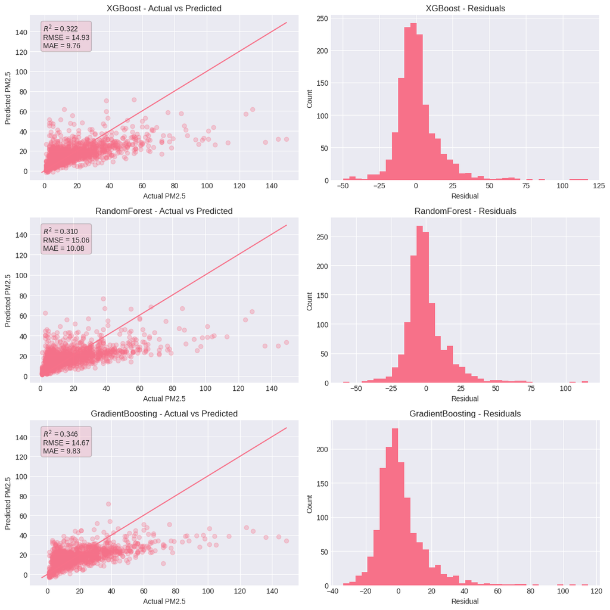

```python
import matplotlib.pyplot as plt
import numpy as np
# from sklearn.metrics import r2_score, mean_squared_error, mean_absolute_error


fig, axes = plt.subplots(3, 2, figsize=(12, 12))

y_true = y_test_model.values
model_names = list(predictions.keys())

for i, name in enumerate(model_names):
    y_pred = predictions[name]

    r2 = r2_score(y_true, y_pred)
    rmse = np.sqrt(mean_squared_error(y_true, y_pred))
    mae = mean_absolute_error(y_true, y_pred)

    print(f"Model: {name}")
    print(f"  R²   = {r2:.4f}")
    print(f"  RMSE = {rmse:.4f}")
    print(f"  MAE  = {mae:.4f}")
    print("-" * 30)

    # Actual vs Predicted
    axes[i, 0].scatter(y_true, y_pred, alpha=0.3)
    mn = min(y_true.min(), y_pred.min())
    mx = max(y_true.max(), y_pred.max())
    axes[i, 0].plot([mn, mx], [mn, mx])

    axes[i, 0].set_title(f"{name} - Actual vs Predicted")
    axes[i, 0].set_xlabel("Actual PM2.5")
    axes[i, 0].set_ylabel("Predicted PM2.5")

    axes[i, 0].text(
        0.05, 0.95,
        f"$R^2$ = {r2:.3f}\nRMSE = {rmse:.2f}\nMAE = {mae:.2f}",
        transform=axes[i, 0].transAxes,
        fontsize=10,
        verticalalignment="top",
        bbox=dict(boxstyle="round", alpha=0.2)
    )

    # errors = np.abs(y_true - y_pred)
    # sc = axes[i, 0].scatter(y_true, y_pred, c=errors, cmap="viridis", alpha=0.4)
    # plt.colorbar(sc, ax=axes[i, 0], label="Absolute error")


    # Residuals
    residuals = y_true - y_pred
    axes[i, 1].hist(residuals, bins=40)
    axes[i, 1].set_title(f"{name} - Residuals")
    axes[i, 1].set_xlabel("Residual")
    axes[i, 1].set_ylabel("Count")

plt.tight_layout()
plt.show()
```

### Rezultati

- Model: XGBoost
  - R² = 0.3091
  - RMSE = 15.1953
  - MAE = 9.8706
- Model: RandomForest
  - R² = 0.3006
  - RMSE = 15.2892
  - MAE = 10.1662
- Model: GradientBoosting
  - R² = 0.3389
  - RMSE = 14.8640
  - MAE = 9.9191

Na testni množici so vsi modeli dosegli nižjo napovedno uspešnost v primerjavi z rezultati 10-fold cross-validacije, kar kaže na omejeno generalizacijo zaradi kompleksnosti procesa. Med testiranimi modeli je GradientBoostingRegressor dosegel najboljše ravnotežje med prileganjem in stabilnostjo (R² = 0.339, RMSE = 14.86), zato je bil izbran kot najbolj zanesljiv model za nadaljnjo analizo in simulacije.

## 2.b Klasifikacijski problem - gradnja in ocenjevanje modelov

Poleg regresijskega problema smo obravnavali tudi klasifikacijski problem, kjer je odvisna spremenljivka binarna.

Ciljna spremenljivka *pm2.5_nezravo* označuje, ali koncentracija PM2.5 presega mejno vrednost za nezdravo kakovost zraka (25 µg/m³).

Za napoved nezdravih razmer smo uporabili več klasifikacijskih algoritmov ter jih ovrednotili z uporabo 10-kratne stratificirane navzkrižne validacije (Stratified K-Fold), kar zagotavlja uravnoteženo porazdelitev razredov v učnih in validacijskih množicah.

Uspešnost modelov smo ocenili z naslednjimi metrikami:

- točnost (Accuracy),
- ploščina pod ROC krivuljo (AUC),
- občutljivost (Sensitivity / Recall),
- pozitivna napovedna vrednost (PPV / Precision),
- F1-merilo.

Rezultati predstavljajo povprečne vrednosti metrik čez vse validacijske razdelitve in omogočajo neposredno primerjavo uspešnosti posameznih klasifikacijskih modelov.

```python
import numpy as np
import pandas as pd

from sklearn.model_selection import StratifiedKFold, cross_validate
from sklearn.preprocessing import StandardScaler
from sklearn.pipeline import Pipeline

from sklearn.linear_model import LogisticRegression
from sklearn.ensemble import RandomForestClassifier, GradientBoostingClassifier
from sklearn.svm import SVC
from xgboost import XGBClassifier


# features and target
features = [
    "temperature",
    "wind",
    "humidity",
    "nadm_visina",
    "population_density_in_1000_m_radius",
    "ura_od_num",
]

target = "pm2.5_nezravo"

# prepare data
df_cls = df.copy()
df_cls = df_cls.dropna(subset=features + [target])

X_classifier = df_cls[features]
y_classifier = df_cls[target].astype(int)

# cross-validation setup
cv = StratifiedKFold(n_splits=10, shuffle=True, random_state=42)

scoring = {
    "accuracy": "accuracy",
    "roc_auc": "roc_auc",
    "recall": "recall",                 # sensitivity
    "precision": "precision",           # PPV
    "f1": "f1",
}


# models
models = {
    "LogisticRegression": Pipeline([
        ("scaler", StandardScaler()),
        ("model", LogisticRegression(max_iter=1000, random_state=42))
    ]),
    "RandomForest": RandomForestClassifier(
        n_estimators=300,
        random_state=42,
        n_jobs=-1
    ),
    "GradientBoosting": GradientBoostingClassifier(
        n_estimators=300,
        learning_rate=0.05,
        random_state=42
    ),
    "SVM": Pipeline([
        ("scaler", StandardScaler()),
        ("model", SVC(kernel="rbf", probability=True, random_state=42))
    ]),
    "XGBoost": XGBClassifier(
        n_estimators=300,
        max_depth=4,
        learning_rate=0.05,
        subsample=0.8,
        colsample_bytree=0.8,
        random_state=42,
        eval_metric="logloss"
    ),
}


# run cross-validation
rows = []

for name, model in models.items():
    scores = cross_validate(
        model,
        X_classifier,
        y_classifier,
        cv=cv,
        scoring=scoring,
        return_train_score=False
    )

    rows.append({
        "Model": name,
        "Accuracy": scores["test_accuracy"].mean(),
        "AUC": scores["test_roc_auc"].mean(),
        "Sensitivity": scores["test_recall"].mean(),
        "PPV": scores["test_precision"].mean(),
        "F1": scores["test_f1"].mean(),
    })


results_classification = pd.DataFrame(rows).sort_values("AUC", ascending=False)
results_classification
```

|  | Model | Accuracy | AUC | Sensitivity | PPV | F1 |
| --- | --- | --- | --- | --- | --- | --- |
| 1 | RandomForest | 0.880007 | 0.933719 | 0.715131 | 0.825998 | 0.766161 |
| 4 | XGBoost | 0.841821 | 0.898944 | 0.604412 | 0.771935 | 0.677025 |
| 2 | GradientBoosting | 0.824802 | 0.881197 | 0.539440 | 0.755576 | 0.627953 |
| 3 | SVM | 0.794625 | 0.824210 | 0.393936 | 0.737365 | 0.512701 |
| 0 | LogisticRegression | 0.751005 | 0.743408 | 0.274951 | 0.603193 | 0.376758 |

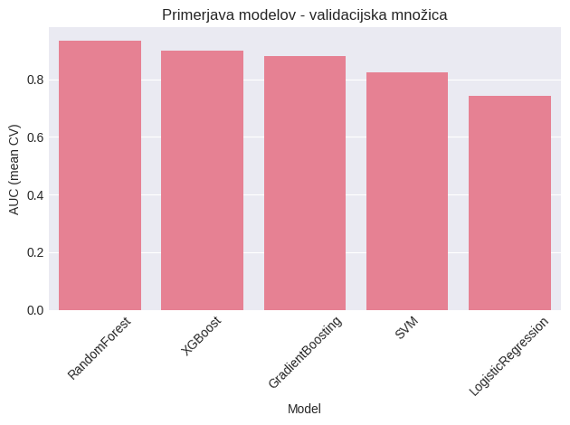

```python
import seaborn as sns
import matplotlib.pyplot as plt

sns.barplot(data=results_classification, x='Model', y='AUC')
plt.xticks(rotation=45)
plt.ylabel("AUC (mean CV)")
plt.title("Primerjava modelov - validacijska množica")
plt.tight_layout()
plt.show()
```

## 3.b Klasifikacijski problem - končno učenje in testiranje modela

Na podlagi rezultatov 10-kratne stratificirane navzkrižne validacije smo kot najboljši klasifikacijski model izbrali naključni gozd (Random Forest).

Izbrani model smo ponovno naučili na celotni učni množici (80 % podatkov), pri čemer smo ohranili časovno urejenost podatkov. Model smo nato ovrednotili na neodvisni testni množici (20 % podatkov), ki ni bila uporabljena pri učenju.

Za oceno napovedne uspešnosti na testni množici smo uporabili matriko zmede (confusion matrix), ki omogoča pregled pravilnih in napačnih klasifikacij ter ločeno analizo zdravih in nezdravih primerov kakovosti zraka.

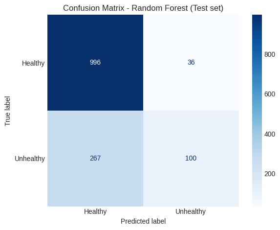

```python
import matplotlib.pyplot as plt
from sklearn.metrics import confusion_matrix, ConfusionMatrixDisplay
from sklearn.ensemble import RandomForestClassifier

# prepare data (same features and target)
df_cm = df.copy()
df_cm = df_cm.dropna(subset=features + [target])

X_classifier = df_cm[features]
y_classifier = df_cm[target].astype(int)

# train/test split (same logic as regression)
split_idx = int(len(df_cm) * 0.8)

X_train_classifier = X_classifier.iloc[:split_idx]
X_test_classifier = X_classifier.iloc[split_idx:]
y_train_classifier = y_classifier.iloc[:split_idx]
y_test_classifier = y_classifier.iloc[split_idx:]

# train best classifier
clf = RandomForestClassifier(
    n_estimators=300,
    random_state=42,
    n_jobs=-1
)

clf.fit(X_train_classifier, y_train_classifier)

# predictions
y_pred = clf.predict(X_test_classifier)

# confusion matrix
cm = confusion_matrix(y_test_classifier, y_pred)

disp = ConfusionMatrixDisplay(
    confusion_matrix=cm,
    display_labels=["Healthy", "Unhealthy"]
)

disp.plot(cmap="Blues")
plt.grid(False)
plt.title("Confusion Matrix - Random Forest (Test set)")
plt.tight_layout()
plt.show()
```

## 3.c Klasifikacijski problem - izboljšanje zaznavanja nezdravih primerov

Pri osnovnem klasifikacijskem modelu smo opazili, da je število lažno negativnih primerov relativno visoko, kar pomeni, da nekateri primeri nezdrave kakovosti zraka niso bili pravilno zaznani.

Ker je v kontekstu kakovosti zraka pomembnejše zaznati nezdrave razmere kot minimizirati lažno pozitivne napovedi, smo izvedli dodatno analizo z namenom izboljšanja občutljivosti (Sensitivity).

Uporabili smo naslednje pristope:

- uravnoteženje razredov z uporabo uteži razredov (*class_weight = "balanced"*),
- prilagoditev odločitvenega praga pri napovedovanju verjetnosti,
- analizo razmerja med natančnostjo (PPV) in občutljivostjo z uporabo Precision–Recall krivulj.

Izboljšave smo ovrednotili na isti testni množici z uporabo matrike zmede ter grafičnega prikaza Precision–Recall krivulj za posamezne modele.

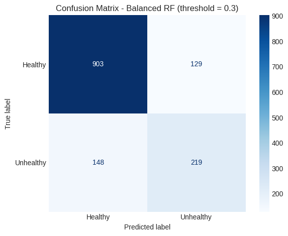

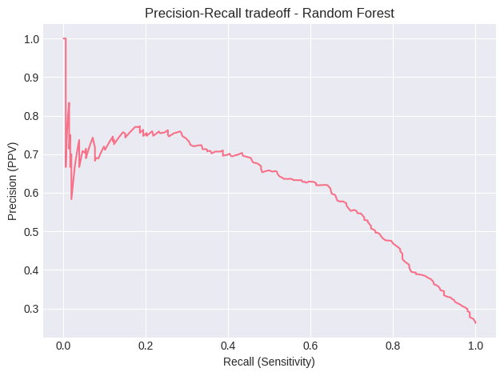

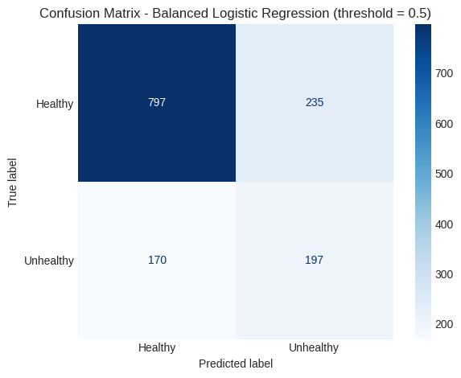

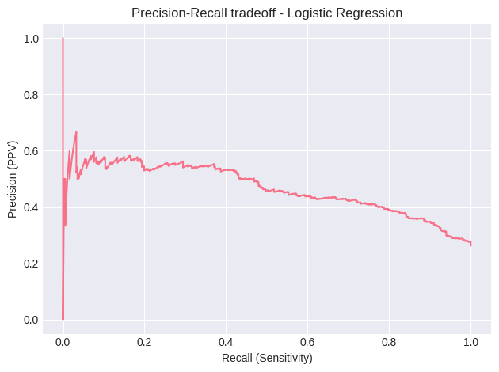

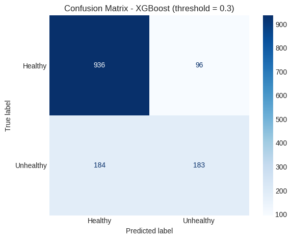

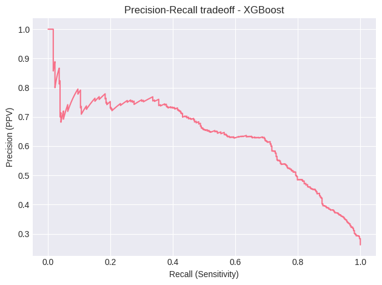

```python
import numpy as np
import matplotlib.pyplot as plt
from sklearn.metrics import (
    confusion_matrix,
    ConfusionMatrixDisplay,
    precision_recall_curve
)
from sklearn.ensemble import RandomForestClassifier
from sklearn.linear_model import LogisticRegression
from xgboost import XGBClassifier
from sklearn.preprocessing import StandardScaler
from sklearn.pipeline import Pipeline
import joblib

# prepare data (same split as before)
df_fix = df.copy()
df_fix = df_fix.dropna(subset=features + [target])

X = df_fix[features]
y = df_fix[target].astype(int)

split_idx = int(len(df_fix) * 0.8)

X_train_classifier = X.iloc[:split_idx]
X_test_classifier = X.iloc[split_idx:]
y_train_classifier = y.iloc[:split_idx]
y_test_classifier = y.iloc[split_idx:]

threshold = 0.3

# 1) RANDOM FOREST (balanced)

rf_balanced = RandomForestClassifier(
    n_estimators=300,
    random_state=42,
    n_jobs=-1,
    class_weight="balanced"
)

rf_balanced.fit(X_train_classifier, y_train_classifier)
y_prob_rf = rf_balanced.predict_proba(X_test_classifier)[:, 1]
y_pred_rf = (y_prob_rf >= 0.3).astype(int)

joblib.dump(rf_balanced, "final_classifier_RandomForest.joblib")

cm_rf = confusion_matrix(y_test_classifier, y_pred_rf)
ConfusionMatrixDisplay(cm_rf, display_labels=["Healthy", "Unhealthy"]) \
    .plot(cmap="Blues")
plt.title(f"Confusion Matrix - Balanced RF (threshold = {0.3})")
plt.grid(False)
plt.tight_layout()
plt.show()

precision, recall, _ = precision_recall_curve(y_test_classifier, y_prob_rf)
plt.figure()
plt.plot(recall, precision)
plt.xlabel("Recall (Sensitivity)")
plt.ylabel("Precision (PPV)")
plt.title("Precision-Recall tradeoff - Random Forest")
plt.tight_layout()
plt.show()



# 2) LOGISTIC REGRESSION (balanced)

logreg = Pipeline([
    ("scaler", StandardScaler()),
    ("model", LogisticRegression(
        max_iter=1000,
        class_weight="balanced",
        random_state=42
    ))
])

logreg.fit(X_train_classifier, y_train_classifier)
y_prob_lr = logreg.predict_proba(X_test_classifier)[:, 1]
y_pred_lr = (y_prob_lr >= 0.5).astype(int)

joblib.dump(logreg, "final_classifier_LogisticRegression.joblib")

cm_lr = confusion_matrix(y_test_classifier, y_pred_lr)
ConfusionMatrixDisplay(cm_lr, display_labels=["Healthy", "Unhealthy"]) \
    .plot(cmap="Blues")
plt.title(f"Confusion Matrix - Balanced Logistic Regression (threshold = {0.5})")
plt.grid(False)
plt.tight_layout()
plt.show()

precision, recall, _ = precision_recall_curve(y_test_classifier, y_prob_lr)
plt.figure()
plt.plot(recall, precision)
plt.xlabel("Recall (Sensitivity)")
plt.ylabel("Precision (PPV)")
plt.title("Precision-Recall tradeoff - Logistic Regression")
plt.tight_layout()
plt.show()


# 3) XGBOOST (threshold tuning)
xgb = XGBClassifier(
    n_estimators=300,
    max_depth=4,
    learning_rate=0.05,
    subsample=0.8,
    colsample_bytree=0.8,
    random_state=42,
    eval_metric="logloss"
)

xgb.fit(X_train_classifier, y_train_classifier)
y_prob_xgb = xgb.predict_proba(X_test_classifier)[:, 1]
y_pred_xgb = (y_prob_xgb >= 0.3).astype(int)

joblib.dump(xgb, "final_classifier_XGBoost.joblib")

cm_xgb = confusion_matrix(y_test_classifier, y_pred_xgb)
ConfusionMatrixDisplay(cm_xgb, display_labels=["Healthy", "Unhealthy"]) \
    .plot(cmap="Blues")
plt.title(f"Confusion Matrix - XGBoost (threshold = {0.3})")
plt.grid(False)
plt.tight_layout()
plt.show()

precision, recall, _ = precision_recall_curve(y_test_classifier, y_prob_xgb)
plt.figure()
plt.plot(recall, precision)
plt.xlabel("Recall (Sensitivity)")
plt.ylabel("Precision (PPV)")
plt.title("Precision-Recall tradeoff - XGBoost")
plt.tight_layout()
plt.show()
```

## 3.d Klasifikacijski problem - primerjava končnih modelov na testni množici

V zadnjem koraku klasifikacijskega dela smo izvedli podrobno primerjavo treh izbranih klasifikacijskih modelov na neodvisni testni množici.

Za vsak model smo:

- ponovno naučili model na učni množici (80 % podatkov),
- uporabili prilagojene odločitvene pragove za napovedovanje razredov,
- ovrednotili napovedno uspešnost na testni množici.

Izračunali smo naslednje metrike:

- točnost (Accuracy),
- občutljivost (Sensitivity / Recall),
- pozitivno napovedno vrednost (PPV / Precision),
- F1-merilo,
- ploščino pod ROC krivuljo (AUC).

Poleg numeričnih metrik smo rezultate predstavili tudi grafično z uporabo matrik zmede ter Precision–Recall krivulj, kar omogoča poglobljeno analizo kompromisa med zaznavanjem nezdravih primerov in natančnostjo napovedi.

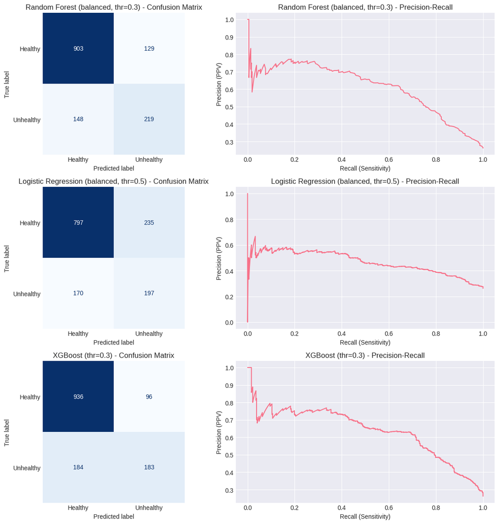

```python
import numpy as np
import matplotlib.pyplot as plt
from sklearn.metrics import (
    confusion_matrix,
    ConfusionMatrixDisplay,
    precision_recall_curve
)
from sklearn.ensemble import RandomForestClassifier
from sklearn.linear_model import LogisticRegression
from xgboost import XGBClassifier
from sklearn.preprocessing import StandardScaler
from sklearn.pipeline import Pipeline
from sklearn.metrics import accuracy_score, recall_score, precision_score, f1_score, roc_auc_score
import joblib

# prepare data (same split as before)
df_fix = df.copy()
df_fix = df_fix.dropna(subset=features + [target])

X_classifier = df_fix[features]
y_classifier = df_fix[target].astype(int)

split_idx = int(len(df_fix) * 0.8)

X_train_classifier = X_classifier.iloc[:split_idx]
X_test_classifier = X_classifier.iloc[split_idx:]
y_train_classifier = y_classifier.iloc[:split_idx]
y_test_classifier = y_classifier.iloc[split_idx:]

# 1) RANDOM FOREST (balanced)
rf_balanced = RandomForestClassifier(
    n_estimators=300,
    random_state=42,
    n_jobs=-1,
    class_weight="balanced"
)

rf_balanced.fit(X_train_classifier, y_train_classifier)
y_prob_rf = rf_balanced.predict_proba(X_test_classifier)[:, 1]
y_pred_rf = (y_prob_rf >= 0.3).astype(int)

accuracy_rf = accuracy_score(y_test_classifier, y_pred_rf)
recall_rf = recall_score(y_test_classifier, y_pred_rf)
precision_rf = precision_score(y_test_classifier, y_pred_rf)
f1_rf = f1_score(y_test_classifier, y_pred_rf)
auc_rf = roc_auc_score(y_test_classifier, y_prob_rf)

joblib.dump(rf_balanced, "final_classifier_RandomForest.joblib")

# 2) LOGISTIC REGRESSION (balanced)
logreg = Pipeline([
    ("scaler", StandardScaler()),
    ("model", LogisticRegression(
        max_iter=1000,
        class_weight="balanced",
        random_state=42
    ))
])

logreg.fit(X_train_classifier, y_train_classifier)
y_prob_lr = logreg.predict_proba(X_test_classifier)[:, 1]
y_pred_lr = (y_prob_lr >= 0.5).astype(int)

accuracy_lr = accuracy_score(y_test_classifier, y_pred_lr)
recall_lr = recall_score(y_test_classifier, y_pred_lr)
precision_lr = precision_score(y_test_classifier, y_pred_lr)
f1_lr = f1_score(y_test_classifier, y_pred_lr)
auc_lr = roc_auc_score(y_test_classifier, y_prob_lr)

joblib.dump(logreg, "final_classifier_LogisticRegression.joblib")

# 3) XGBOOST (threshold tuning)
xgb = XGBClassifier(
    n_estimators=300,
    max_depth=4,
    learning_rate=0.05,
    subsample=0.8,
    colsample_bytree=0.8,
    random_state=42,
    eval_metric="logloss"
)

xgb.fit(X_train_classifier, y_train_classifier)
y_prob_xgb = xgb.predict_proba(X_test_classifier)[:, 1]
y_pred_xgb = (y_prob_xgb >= 0.3).astype(int)

accuracy_xgb = accuracy_score(y_test_classifier, y_pred_xgb)
recall_xgb = recall_score(y_test_classifier, y_pred_xgb)
precision_xgb = precision_score(y_test_classifier, y_pred_xgb)
f1_xgb = f1_score(y_test_classifier, y_pred_xgb)
auc_xgb = roc_auc_score(y_test_classifier, y_prob_xgb)

joblib.dump(xgb, "final_classifier_XGBoost.joblib")

# plotting: 2 graphs per row
models_data = [
    {
        "name": "Random Forest (balanced, thr=0.3)",
        "y_prob": y_prob_rf,
        "y_pred": y_pred_rf
    },
    {
        "name": "Logistic Regression (balanced, thr=0.5)",
        "y_prob": y_prob_lr,
        "y_pred": y_pred_lr
    },
    {
        "name": "XGBoost (thr=0.3)",
        "y_prob": y_prob_xgb,
        "y_pred": y_pred_xgb
    }
]

fig, axes = plt.subplots(len(models_data), 2, figsize=(12, 12))

for i, m in enumerate(models_data):
    cm = confusion_matrix(y_test_classifier, m["y_pred"])
    disp = ConfusionMatrixDisplay(
        confusion_matrix=cm,
        display_labels=["Healthy", "Unhealthy"]
    )
    disp.plot(ax=axes[i, 0], cmap="Blues", colorbar=False)
    axes[i, 0].set_title(f"{m['name']} - Confusion Matrix")
    axes[i, 0].grid(False)

    precision, recall, _ = precision_recall_curve(y_test_classifier, m["y_prob"])
    axes[i, 1].plot(recall, precision)
    axes[i, 1].set_xlabel("Recall (Sensitivity)")
    axes[i, 1].set_ylabel("Precision (PPV)")
    axes[i, 1].set_title(f"{m['name']} - Precision-Recall")

plt.tight_layout()
plt.show()
```

### Primerjava končnih klasifikacijskih modelov na testni množici

Za vse izbrane klasifikacijske modele smo na neodvisni testni množici izračunali ključne metrike napovedne uspešnosti. Tabela prikazuje neposredno primerjavo modelov glede na točnost, občutljivost, pozitivno napovedno vrednost, F1-merilo in ploščino pod ROC krivuljo (AUC).

Rezultati omogočajo oceno kompromisa med zaznavanjem nezdravih primerov in natančnostjo napovedi ter služijo kot osnova za izbor modela za nadaljnje analize.

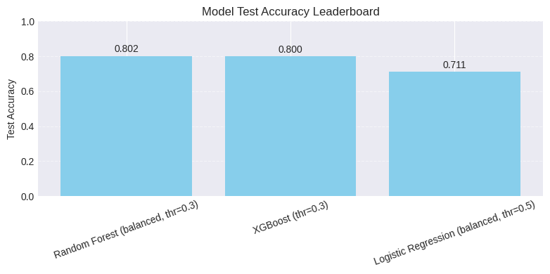

|  | Model | Accuracy | Sensitivity (Recall) | PPV (Precision) | F1-score | AUC |
| --- | --- | --- | --- | --- | --- | --- |
| 0 | Random Forest (balanced, thr=0.3) | 0.802001 | 0.596730 | 0.629310 | 0.612587 | 0.811870 |
| 2 | XGBoost (thr=0.3) | 0.799857 | 0.498638 | 0.655914 | 0.566563 | 0.833035 |
| 1 | Logistic Regression (balanced, thr=0.5) | 0.710508 | 0.536785 | 0.456019 | 0.493116 | 0.736965 |

```python
comparison_test = pd.DataFrame({
    "Model": [
        "Random Forest (balanced, thr=0.3)",
        "Logistic Regression (balanced, thr=0.5)",
        "XGBoost (thr=0.3)"
    ],
    "Accuracy": [
        accuracy_rf,
        accuracy_lr,
        accuracy_xgb
    ],
    "Sensitivity (Recall)": [
        recall_rf,
        recall_lr,
        recall_xgb
    ],
    "PPV (Precision)": [
        precision_rf,
        precision_lr,
        precision_xgb
    ],
    "F1-score": [
        f1_rf,
        f1_lr,
        f1_xgb
    ],
    "AUC": [
        auc_rf,
        auc_lr,
        auc_xgb
    ]
})

comparison_sorted = comparison_test.sort_values(by="Accuracy", ascending=False)

plt.figure(figsize=(8,4))
bars = plt.bar(comparison_sorted["Model"], comparison_sorted["Accuracy"], color="skyblue")
plt.ylabel("Test Accuracy")
plt.title("Model Test Accuracy Leaderboard")
plt.ylim([0, 1])
plt.grid(axis="y", linestyle="--", alpha=0.5)

for bar in bars:
    height = bar.get_height()
    plt.text(bar.get_x() + bar.get_width()/2, height + 0.01, f"{height:.3f}",
             ha='center', va='bottom', fontsize=10)

plt.xticks(rotation=20)
plt.tight_layout()
plt.show()

comparison_sorted
```

## 4. Interaktivna aplikacija – simulacija in optimizacija procesa

V okviru seminarske naloge smo razvili interaktivno aplikacijo (implementirano v datoteki *app.py* z uporabo ogrodja Streamlit), ki temelji na že naučenih regresijskih in klasifikacijskih modelih. Namen aplikacije je omogočiti napoved koncentracije PM2.5, oceno kakovosti zraka ter simulacijo izboljšav procesa na podlagi modelnih napovedi.

### 4.1 Izbira modela

Aplikacija omogoča uporabniku izbiro enega izmed treh najboljših regresijskih modelov za napoved koncentracije PM2.5 ter enega izmed treh klasifikacijskih modelov za oceno verjetnosti nezdrave kakovosti zraka. Izbrani modeli se dinamično naložijo iz shranjenih datotek in se uporabijo v vseh nadaljnjih izračunih.

### 4.2 Napoved za posamezen vzorec

Uporabnik prek uporabniškega vmesnika vnese vrednosti okoljskih in prostorskih spremenljivk (temperatura, hitrost vetra, vlažnost, nadmorska višina, gostota prebivalstva in ura dneva). Na podlagi vnesenih podatkov aplikacija izračuna:

- napovedano koncentracijo PM2.5 z regresijskim modelom,
- verjetnost nezdrave kakovosti zraka s klasifikacijskim modelom,
- odločitev o zdravem ali nezdravem stanju glede na izbrani prag verjetnosti.

### 4.3 Simulacija sprememb in optimizacija procesa

Aplikacija izvaja modelno vodeno simulacijo izboljšanja kakovosti zraka. Na podlagi trenutnih vhodnih pogojev sistem preizkusi lokalne spremembe temperature in hitrosti vetra ter izbere kombinacijo, ki minimizira napovedano koncentracijo PM2.5.

Tukaj je ta pristop dodatno prikazan z deterministično simulacijo v obliki toplotne karte (heatmap), kjer so sistematično analizirani vplivi temperature in hitrosti vetra na napovedano koncentracijo PM2.5 pri fiksnih ostalih pogojih.

Rezultati simulacije vključujejo primerjavo stanja pred in po spremembah, grafični prikaz razlik ter možnost izvoza rezultatov v CSV datoteko. Ta pristop omogoča simulacijo optimizacije procesa in podporo odločanju glede potencialnih okoljskih izboljšav.

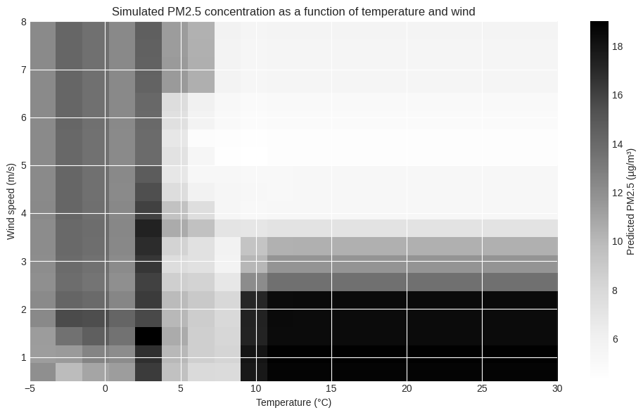

```python
import numpy as np
import pandas as pd
import matplotlib.pyplot as plt
import joblib

reg_model = joblib.load("final_model_RandomForest.joblib")

# baseline values (use medians for stability)
baseline = {
    "humidity": df["humidity"].median(),
    "nadm_visina": df["nadm_visina"].median(),
    "population_density_in_1000_m_radius": df["population_density_in_1000_m_radius"].median(),
    "ura_od_num": 12,
}

# simulation ranges
temperature_range = np.linspace(-5, 30, 20)
wind_range = np.linspace(0.5, 8, 20)

pm25_grid = np.zeros((len(wind_range), len(temperature_range)))

# generate grid predictions
for i, wind in enumerate(wind_range):
    for j, temp in enumerate(temperature_range):
        X_sim = pd.DataFrame([{
            "temperature": temp,
            "wind": wind,
            "humidity": baseline["humidity"],
            "nadm_visina": baseline["nadm_visina"],
            "population_density_in_1000_m_radius": baseline["population_density_in_1000_m_radius"],
            "ura_od_num": baseline["ura_od_num"],
        }])

        pm25_grid[i, j] = reg_model.predict(X_sim)[0]

# plot heatmap
plt.figure(figsize=(10, 6))
plt.imshow(
    pm25_grid,
    origin="lower",
    aspect="auto",
    extent=[
        temperature_range.min(),
        temperature_range.max(),
        wind_range.min(),
        wind_range.max()
    ]
)

plt.colorbar(label="Predicted PM2.5 (µg/m³)")
plt.xlabel("Temperature (°C)")
plt.ylabel("Wind speed (m/s)")
plt.title("Simulated PM2.5 concentration as a function of temperature and wind")
plt.tight_layout()
plt.show()
```

## 5. Povzetek ugotovitev in priporočila za optimizacijo

Opazovani vplivi posameznih spremenljivk temeljijo na odzivih iz interaktivne aplikacije in modelno vodenih simulacij, kjer so bile posamezne vhodne spremenljivke spreminjane ob nespremenjenih ostalih pogojih.

Na podlagi teh ugotovitev so procesno smiselne predvsem spremembe, ki zmanjšujejo zadrževanje onesnaženega zraka, kot so izboljšano prezračevanje urbanih območij, spodbujanje naravnega kroženja zraka ter časovno prilagojeni ukrepi v obdobjih, ko so koncentracije PM2.5 najvišje.

Vodstvu priporočamo uporabo modelno podprtih simulacij kot orodja za odločanje pri načrtovanju okoljskih in urbanističnih ukrepov. Rezultati kažejo, da lahko tudi relativno majhne sistemske izboljšave vodijo do merljivega zmanjšanja onesnaženosti zraka in izboljšanja kakovosti okolja.

## 6. Testiranje globalnih sprememb (Simulacije PREJ in POTEM)

Na podlagi rezultatov simulacij iz prejšnjega poglavja smo definirali globalne spremembe vhodnih pogojev, ki predstavljajo procesno smiselne izboljšave kakovosti zraka.

Kot globalni izboljšavi smo izbrali:

- povečanje temperature za +2 °C,
- povečanje hitrosti vetra za +1 m/s.

```python
import pandas as pd
import numpy as np
import joblib

# load final regression model
models = {
    "Regression": {
        "RandomForest": joblib.load("final_model_RandomForest.joblib"),
        "XGBoost": joblib.load("final_model_XGBoost.joblib"),
        "GradientBoosting": joblib.load("final_model_GradientBoosting.joblib")
    },
    "Classification": {
        "RandomForest": joblib.load("final_classifier_RandomForest.joblib"),
        "LogisticRegression": joblib.load("final_classifier_LogisticRegression.joblib"),
        "XGBoost": joblib.load("final_classifier_XGBoost.joblib")
    }
}

# original test set (PRE)
X_test_pre = X_test_model.copy()

y_test_regression_pre = y_test_model.copy()
y_test_classification_pre = y_test_classifier.copy()

# POST: apply global changes
X_test_post = X_test_model.copy()
X_test_post["temperature"] = X_test_post["temperature"] + 2.0
X_test_post["wind"] = X_test_post["wind"] + 1.0

# prevent unrealistic values
X_test_post["wind"] = X_test_post["wind"].clip(lower=0.1)
```

Za oceno vpliva globalnih sprememb smo pripravili dve različici testne množice:

- **PREJ**: originalna testna množica brez sprememb,
- **POTEM**: testna množica z uvedenimi globalnimi izboljšavami temperature in hitrosti vetra.

Na obeh množicah smo uporabili isti že naučen regresijski model. Namen analize ni ponovno vrednotenje napovedne natančnosti modela, temveč simulacija procesa: primerjava, kako se ob sistemskih spremembah vhodnih pogojev spremenijo napovedane koncentracije PM2.5 (povprečje, sprememba in delež primerov z izboljšanjem).

Ker se pri simulaciji vhodni pogoji namensko spremenijo, realne izmerjene vrednosti ostanejo enake, zato klasične metrike kot R² niso glavni pokazatelj uspešnosti procesa, zdelo se nama je bolj smiselno spremljati spremembo napovedanih koncentracij PM2.5.

```python
process_rows = []

for model_name, reg_model in models["Regression"].items():
    # napovedi
    y_pred_pre = reg_model.predict(X_test_pre)
    y_pred_post = reg_model.predict(X_test_post)

    delta = y_pred_post - y_pred_pre

    process_rows.append({
        "Model": model_name,
        "PM2.5 mean PRE": np.mean(y_pred_pre),
        "PM2.5 mean POST": np.mean(y_pred_post),
        "Mean change (POST-PRE)": np.mean(delta),

        "% improved (delta < 0)": np.mean(delta < 0) * 100
    })

process_comparison_df = pd.DataFrame(process_rows)
process_comparison_df
```

|  | Model | PM2.5 mean PRE | PM2.5 mean POST | Mean change (POST-PRE) | % improved (delta < 0) |
| --- | --- | --- | --- | --- | --- |
| 0 | RandomForest | 18.602731 | 14.415863 | -4.186868 | 83.488206 |
| 1 | XGBoost | 17.598656 | 13.632874 | -3.965782 | 78.556112 |
| 2 | GradientBoosting | 17.478519 | 13.619938 | -3.858581 | 83.631165 |

```python
rows_cls = []

for model_name, clf_model in models["Classification"].items():

    # predicted probabilities
    prob_pre = clf_model.predict_proba(X_test_pre)[:, 1]
    prob_post = clf_model.predict_proba(X_test_post)[:, 1]

    delta = prob_post - prob_pre

    rows_cls.append({
        "Model": model_name,
        "Mean risk PRE": np.mean(prob_pre),
        "Mean risk POST": np.mean(prob_post),
        "Mean change (POST-PRE)": np.mean(delta),
        "% improved (delta < 0)": np.mean(delta < 0) * 100,
    })

classification_simulation_summary = pd.DataFrame(rows_cls)
classification_simulation_summary
```

|  | Model | Mean risk PRE | Mean risk POST | Mean change (POST-PRE) | % improved (delta < 0) |
| --- | --- | --- | --- | --- | --- |
| 0 | RandomForest | 0.201806 | 0.112576 | -0.089230 | 77.412437 |
| 1 | LogisticRegression | 0.404105 | 0.253825 | -0.150279 | 100.000000 |
| 2 | XGBoost | 0.181541 | 0.103700 | -0.077841 | 84.131523 |

| Model | Metrika | Pred | Po | Razlika | Delež izboljšav (%) | Interpretacija |
| --- | --- | --- | --- | --- | --- | --- |
| RandomForest | Povprečna PM2.5 (µg/m³) | 18.60 | 14.42 | −4.19 | 83.49 % | Znatno znižanje napovedane koncentracije PM2.5 po simuliranih izboljšavah |
| XGBoost | Povprečna PM2.5 (µg/m³) | 17.60 | 13.63 | −3.97 | 78.56 % | Konsistentno izboljšanje kakovosti zraka |
| GradientBoosting | Povprečna PM2.5 (µg/m³) | 17.48 | 13.62 | −3.86 | 83.63 % | Stabilno zmanjšanje napovedanih koncentracij |

| Model | Metrika | Pred | Po | Razlika | Delež izboljšav (%) | Interpretacija |
| --- | --- | --- | --- | --- | --- | --- |
| RandomForest | Povprečna verjetnost nezdravega zraka | 0.202 | 0.113 | −0.089 | 77.41 % | Zmanjšano tveganje nezdrave kakovosti zraka |
| LogisticRegression | Povprečna verjetnost nezdravega zraka | 0.404 | 0.254 | −0.150 | 100 % | Največji absolutni padec tveganja |
| XGBoost | Povprečna verjetnost nezdravega zraka | 0.182 | 0.104 | −0.078 | 84.13 % | Stabilno zmanjšanje verjetnosti tveganja |

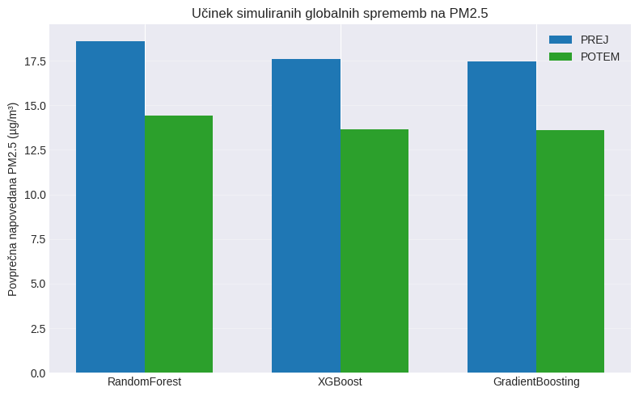

```python
import matplotlib.pyplot as plt
import numpy as np

# podatki
models = process_comparison_df["Model"]
pre = process_comparison_df["PM2.5 mean PRE"]
post = process_comparison_df["PM2.5 mean POST"]

x = np.arange(len(models))
width = 0.35

plt.figure(figsize=(8, 5))

plt.bar(x - width/2, pre, width, label="PREJ", color="tab:blue")
plt.bar(x + width/2, post, width, label="POTEM", color="tab:green")

plt.xticks(x, models)
plt.ylabel("Povprečna napovedana PM2.5 (µg/m³)")
plt.title("Učinek simuliranih globalnih sprememb na PM2.5")
plt.legend()
plt.grid(axis="y", alpha=0.3)

plt.tight_layout()
plt.show()
```

## 7. Six Sigma analiza - kvantitativna ocena izboljšave procesa

V tem poglavju sva uporabila Six Sigma metodologijo za kvantitativno oceno izboljšave procesa po uvedbi globalnih sprememb, opisanih v prejšnjem poglavju. Namen analize je bil objektivno ovrednotiti, ali simulirane spremembe vhodnih pogojev vodijo do statistično in procesno pomembnega zmanjšanja nezaželenih izidov.

### Definicija defekta

**Klasifikacijki modeli**

- Kot **defekt** sva definirala nezaželen izid procesa, pri katerem model napove nezdravo kakovost zraka (pozitiven razred). Tak izid predstavlja stanje, ki ga želimo z vidika kakovosti zraka in upravljanja procesa zmanjšati.

**Regresijski modeli**

- Kot **defekt** sva definirala napoved koncentracije PM2.5, ki presega tolerančno mejo 25 µg/m³, kar ustreza mejni vrednosti za nezdravo kakovost zraka. Ta prag omogoča neposredno procesno interpretacijo napovedi regresijskih modelov.

Analiza je bila izvedena ločeno za:

- **PREJ**: napovedi klasifikacijskega modela na izvirni testni množici,
- **POTEM**: napovedi klasifikacijskega modela na testni množici z uvedenimi globalnimi izboljšavami vhodnih pogojev.

Za vsako stanje smo izračunali:

- število defektov,
- DPMO,
- pripadajoči sigma nivo.

```python
from scipy.stats import norm
import pandas as pd
import numpy as np

def six_sigma_from_predictions(model_name, y_pred, regression=False, threshold=25):

    dpmos = []
    sigmas = []

    for y_pred in y_pred:
        if regression:
            defects = np.sum(y_pred > threshold)
        else:
            defects = np.sum(y_pred == 1)

        opportunities = len(y_pred)
        dpmo = (defects / opportunities) * 1_000_000
        sigmas.append(norm.ppf(1 - dpmo / 1_000_000) + 1.5)
        dpmos.append(dpmo)

    return {
        "Model": model_name,
        "DPMO PRE": dpmos[0],
        "Sigma nivo PRE": sigmas[0],
        "DPMO POST": dpmos[1],
        "Sigma nivo POST": sigmas[1],
        "Izboljšava six sigma": sigmas[1] - sigmas[0],
        "Izboljšava DPMO": (dpmos[1] - dpmos[0]) / dpmos[0] * 100,
    }

rows_cls = []
# Classification
for model_name, cls_model in models["Classification"].items():
    # predicted probabilities
    y_prob_pre = cls_model.predict_proba(X_test_pre)[:, 1]
    y_prob_post = cls_model.predict_proba(X_test_post)[:, 1]

    y_pred_pre = (y_prob_pre >= threshold).astype(int)
    y_pred_post = (y_prob_post >= threshold).astype(int)

    rows_cls.append(six_sigma_from_predictions(model_name, [y_pred_pre, y_pred_post]))

classification_six_sigma_summary = pd.DataFrame(rows_cls)

rows_reg = []
for model_name, reg_model in models["Regression"].items():
    # napovedi
    y_pred_pre = reg_model.predict(X_test_pre)
    y_pred_post = reg_model.predict(X_test_post)

    rows_reg.append(six_sigma_from_predictions(model_name, [y_pred_pre, y_pred_post], regression=True))

regression_six_sigma_summary = pd.DataFrame(rows_reg)
```

```python
classification_six_sigma_summary
```

|  | Model | DPMO PRE | Sigma nivo PRE | DPMO POST | Sigma nivo POST | Izboljšava six sigma | Izboljšava DPMO |
| --- | --- | --- | --- | --- | --- | --- | --- |
| 0 | RandomForest | 250893.495354 | 2.171681 | 112937.812723 | 2.711052 | 0.539371 | -54.985755 |
| 1 | LogisticRegression | 692637.598284 | 0.996659 | 339528.234453 | 1.913751 | 0.917092 | -50.980392 |
| 2 | XGBoost | 200142.959257 | 2.341111 | 105789.849893 | 2.749233 | 0.408123 | -47.142857 |

```python
regression_six_sigma_summary
```

|  | Model | DPMO PRE | Sigma nivo PRE | DPMO POST | Sigma nivo POST | Izboljšava six sigma | Izboljšava DPMO |
| --- | --- | --- | --- | --- | --- | --- | --- |
| 0 | RandomForest | 191565.403860 | 2.372142 | 92923.516798 | 2.822965 | 0.450823 | -51.492537 |
| 1 | XGBoost | 179413.867048 | 2.417601 | 92208.720515 | 2.827276 | 0.409675 | -48.605578 |
| 2 | GradientBoosting | 169406.719085 | 2.456512 | 96497.498213 | 2.801770 | 0.345258 | -43.037975 |

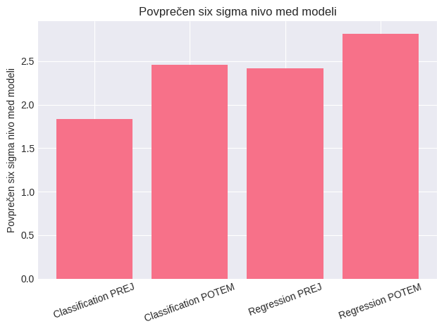

```python
import matplotlib.pyplot as plt
import numpy as np

# Extract sigma values from your summaries
cls_pre = classification_six_sigma_summary["Sigma nivo PRE"].values
cls_post = classification_six_sigma_summary["Sigma nivo POST"].values

reg_pre = regression_six_sigma_summary["Sigma nivo PRE"].values
reg_post = regression_six_sigma_summary["Sigma nivo POST"].values

# Compute averages
avg_values = [
    np.mean(cls_pre),
    np.mean(cls_post),
    np.mean(reg_pre),
    np.mean(reg_post),
]

labels = [
    "Classification PREJ",
    "Classification POTEM",
    "Regression PREJ",
    "Regression POTEM",
]

# Plot
plt.figure()
plt.bar(labels, avg_values)
plt.ylabel("Povprečen six sigma nivo med modeli")
plt.title("Povprečen six sigma nivo med modeli")
plt.xticks(rotation=20)
plt.tight_layout()
plt.show()
```

### Klasifikacijski modeli

**RandomForest**

- Sigma PRE: 2.17
- Sigma POST: 2.71
- Izboljšava: +0.54 σ

DPMO: ~251k → ~113k (–55 % defektov)

Po uvedbi globalnih sprememb se je število napovedi nezdrave kakovosti zraka skoraj prepolovilo. Prehod iz približno 2.2 σ na 2.7 σ predstavlja konkreten procesni napredek v Six Sigma in jasno kaže izboljšanje stabilnosti procesa.

**LogisticRegression**

- Sigma PRE: 1.00
- Sigma POST: 1.91 -Izboljšava: +0.92 σ

DPMO: ~692,600 → ~339,500 (–51 % defektov)

Čeprav logistična regresija izhaja iz slabšega izhodiščnega stanja, kaže največjo relativno izboljšavo sigma nivoja. To pomeni, da je model zelo občutljiv na spremembe vhodnih pogojev.

**XGBoost**

- Sigma PRE: 2.34
- Sigma POST: 2.75
- Izboljšava: +0.41 σ

DPMO: ~200,000 → ~105,800 (–47 % defektov)

XGBoost izkazuje stabilno izboljšanje procesa, z opaznim zmanjšanjem defektov in konsistentnim dvigom sigma nivoja. Rezultati potrjujejo robustnost modela in učinkovitost simuliranih sprememb.

### Regresijski modeli

**RandomForest**

- Sigma PRE: 2.37
- Sigma POST: 2.82
- Izboljšava: +0.45 σ

DPMO: ~191,600 → ~92,900 (–52 % defektov)

Uvedene spremembe so skoraj prepolovile število napovedanih preseganj mejne vrednosti PM2.5, kar pomeni bistveno izboljšanje procesa z vidika okoljskih standardov.

**XGBoost**

- Sigma PRE: 2.42
- Sigma POST: 2.83
- Izboljšava: +0.41 σ

DPMO: ~179,400 → ~92,200 (–49 % defektov)

Model kaže zelo podobno izboljšanje kot RandomForest, kar dodatno potrjuje, da izboljšava ni posledica specifičnega algoritma, temveč spremembe vhodnih pogojev.

**GradientBoosting**

- Sigma PRE: 2.46
- Sigma POST: 2.80
- Izboljšava: +0.35 σ

DPMO: ~169,400 → ~96,400 (–43 % defektov)

Čeprav je izboljšava nekoliko manjša, model še vedno kaže jasno znižanje defektov in izboljšanje sigma nivoja, kar potrjuje konsistentnost rezultatov med modeli.